# Recent political developments in Latin America

A summary of major political shifts in each country since 2000

Author

Philippe Decker

UPDATED

17/11/26

#### Summary

In recent years, Latin America has experienced a rightward shift as voters have turned against incumbent left-wing governments. The trend began in Argentina in 2023, when Javier Milei defeated the Peronist governing coalition, and continued in Bolivia, Chile and Honduras in 2025, where left-led governments lost power. In 2026, the trend continued with Keiko Fujimori’s victory in Peru, while Abelardo De La Espriella’s election in Colombia brought the country’s brief experience of left-wing government to an end.

These electoral shifts also align with the Trump administration’s explicitly stated ambitions for the region. The US National Security Strategy published in November 2025 calls for Washington to “restore American preeminence in the Western Hemisphere” and pledges to “reward and encourage” governments, parties and movements broadly aligned with US principles and strategy (The White House 2025, 15). Trump has also intervened overtly in several electoral campaigns by publicly endorsing ideologically aligned candidates, including in Colombia, Chile and Honduras, and backing Javier Milei’s political camp ahead of Argentina’s 2025 mid-term elections. “Lots of people that I got elected”, he said in September 2026 (Bloomfield 2026). However, these interventions do not by themselves explain the region’s political trajectory. ECLAC’s comparative analysis of 16 Latin American countries found that, between 2015 and 2025, incumbent parties or coalitions lost 74 per cent of presidential elections, compared with 44 per cent between 2003 and 2014 (Salazar-Xirinachs and Boeninger Sempere 2026). Recent continuity cases include Mexico, Paraguay, the Dominican Republic, El Salvador and Ecuador, as well as Costa Rica, where Laura Fernández promised continuity with Rodrigo Chaves. The pattern therefore suggests that the current rightward shift is driven in significant part by a broader cycle of anti-incumbency, in which voters punish governments for perceived failures to deliver on security, economic conditions and other immediate concerns. Since voters have increasingly turned against incumbent left-wing governments in favour of anti-establishment challengers, often radical right-wing or far-right outsiders, this discontent has frequently translated into a shift to the right. US endorsements and political pressure may reinforce that shift, but they are not sufficient to explain it.

[interactive chart not shown]

### Argentina

Argentina’s political trajectory since 2000 has been shaped by recurring economic crises and shifts between governments pursuing different economic models. In 2001, President Fernando de la Rúa’s government imposed the *corralito*, severely restricting withdrawals from bank accounts amid a financial collapse and the subsequent conversion of dollars deposits (a common practice among Argentines to keep savings in dollars due to the volatiliy of the pesos) into pesos at an unfavourable exchange rate. These measures fuelled mass protests and riots that forced him to resign. The crisis paved the way for the election of Néstor Kirchner in 2003, whose Peronist government pursued a more interventionist, centre-left agenda, continued under his wife Cristina Fernández de Kirchner, who succeeded him as president in 2007 following his decision not to seek re-election. Her administrations expanded state involvement in the economy and social spending. In 2015, centre-right candidate Mauricio Macri won the presidency promising market-oriented reforms and closer ties with Western economies. In 2018, Macri’s government secured a US$ 57 billion IMF programme, the largest in the Fund’s history. The arrangement was widely criticised as political support for Macri ahead of the 2019 presidential election as most of the funds were disbursed before the elections (Green 2020). The programme failed to restore economic stability and Macri lost to Peronist candidate Alberto Fernández.

In the 2023 elections, Javier Milei won a resounding victory against the economy minister of Alberto Fernández, Sergio Massa. Fernández did not stand for re-election due to his high impopularity. During Fernández’s government, annual inflation had reached 138 per cent, and Milei’s promise to bring it under control found fertile ground among voters desperate for change. His win marked the beginning of a dramatic ideological shift in Argentina and the wider region; which had been dominated by left-wing governments for much of the preceding decade. Milei describes himself as an “anarcho-capitalist” who sees the state as the enemy and vowed to dismantle what he calls the political caste. His win also marked the beginning of Argentina’s closer realignment with the US.

Milei triumphed again at the midterm elections in October 2025, with his party securing a majority in the legislature. Prior to those elections, the US announced considerable financial assistance to shore up Argentina’s economy (an up to $40 billion bailout package), and President Trump made clear he would consider rescinding it in the event of an opposition victory. While Milei succeeded in bringing inflation under control, the social cost of deep cuts to public spending has dented his initial popularity. His image as an anti-corruption candidate has also taken severe blows, as Milei himself and members of his inner circle have been accused of illicit enrichment. His spokesperson and head of cabinet, Manuel Adorni, was compelled to resign at the end of June 2026 after failing to account for the origin of his sudden and substantial wealth.

In December 2023, Milei rejected the invitation, received during his predecessor’s mandate, to join the enlarged BRICS+ bloc. While during his campaign he vowed to sever all ties with Communist China, this has not materialised in practice given Argentina’s reliance on China as a major trading partner and source of financial support, including a significant currency swap line with the People’s Bank of China. Milei’s administration has also not formally withdrawn from China’s Belt and Road Initiative, which Argentina joined in 2022 with pledges of over $23 billion in Chinese financing and investment. However, criticism of China and its Communist leadership continues among members of the administration. On 30 August 2026, shortly after the devastating floods and landslides on the Nepal-China border, the National Director of Digital Communication, Juan Pablo Carreira Carreira (2026) , published a post on X blaming the management of the Communist Party for the disaster, provoking a formal rebuke from the Chinese embassy (2026) in Buenos Aires.

The next general elections are scheduled for October 2027. Most polls still show Milei ahead, but his political popularity has reached its lowest point since taking office. This context may help explain why the long-standing dispute over the islands known to Britain as the Falklands and to Argentina as the Malvinas has resurfaced on the political agenda. Similar to 1982, when the military junta, facing growing domestic opposition amid mass disappearances and widespread human rights abuses, decided to seize the islands from the United Kingdom, triggering a brief but bloody conflict, it is tempting to see the Malvinas question resurfacing on the political agenda as serving similar domestic political purposes (Tait 2026). Adding a new dimension to the dispute, Trump has signalled that he may reconsider the traditional US position supporting British sovereignty, reportedly as leverage against NATO allies that declined to join the Iran war, while simultaneously seeking to reward partners in the Western Hemisphere.

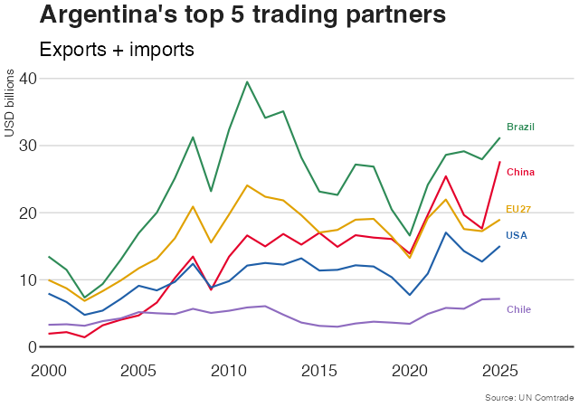

### Belize

Since 2000, Belizean politics has been dominated by alternating governments from the two main parties: the People’s United Party (PUP), broadly associated with the centre-left, and the United Democratic Party (UDP), generally considered centre-right. The PUP government of Said Musa, in office since 1998, won re-election in 2003 but was defeated in 2008 by the UDP under Dean Barrow, following growing concerns about corruption, public debt and economic management. The UDP retained power in 2012 and 2015, before the PUP under John Briceño returned to office in 2020. Briceño won a second consecutive term in March 2025, with the PUP retaining 26 of the 31 seats in parliament while a divided UDP contested the election in rival factions. Although the parties occupy different positions on the political spectrum, Belize has not experienced the sharp ideological swings seen elsewhere in Latin America. While ideology and ethnicity help explain party allegiance, clientelism remains a central feature of the party system and a key mechanism for sustaining electoral loyalty (Ferrell and Wainwright 2023; Inter-Parliamentary Union 2008; Perelló and Navia 2025).

Belize continues to face challenges associated with organised crime, including gang violence, economic dependence on tourism and limited state capacity. A longstanding foreign-policy and security concern is Guatemala’s territorial claim over approximately 53 per cent of Belize’s land territory, which the two countries agreed to submit to the International Court of Justice. Belize’s case illustrates how a small state relies on international law and multilateral institutions to manage disputes that could otherwise threaten its sovereignty. Meanwhile, the 2025 election exposed the weakness of the parliamentary opposition, with the UDP split contributing to another decisive PUP victory. The political system remains competitive, but the dominance of two established parties and the importance of patronage networks raise questions about the scope for new political alternatives (Ferrell and Wainwright 2023; Greater Belize Media 2026a; Perelló and Navia 2025).

Relations with the United States are particularly important because of trade, tourism, migration (the US is home to roughly one-third of all Belizeans) and security cooperation (Ferrell and Wainwright 2023). In October 2025, Briceño’s government signed a US asylum-cooperation agreement under which eligible third-country nationals seeking protection in the United States can be transferred to Belize to have their claims examined. The arrangement became operational in July 2026, though initial transfers involved only a small number of individuals (Janetsky 2025; Love FM Belize 2026). Belize was absent from Trump’s *Shield of the Americas* summit in March 2026 as the country had not been invited, so its absence should not be described as a refusal to join. The exclusion is nevertheless noteworthy given the administration’s emphasis on building a selective coalition of regional governments around security and countering Chinese influence (Greater Belize Media 2026b).

Belize’s most consequential geopolitical commitment is its continued diplomatic recognition of Taiwan, with which it has maintained relations since 1989. It is one of a dwindling group of twelve countries worldwide that retain formal diplomatic ties with Taipei and has no diplomatic relations with the People’s Republic of China. The relationship has brought cooperation in development, health, education, infrastructure and agriculture, but it has also exposed Belize to pressure from Beijing. On 12 October 2026, China sanctioned Belizean Foreign Minister Francis Fonseca over his country’s support for Taiwan, imposing entry restrictions on him in Hong Kong and Macau and prohibiting Chinese organisations and individuals from cooperating with him. Washington condemned China’s actions as coercive (Lee and Blanchard 2026; Reuters 2026d).

Belize therefore combines conventional two-party electoral competition with a foreign policy shaped by the constraints of a small state. Its domestic politics has been shaped more by party networks, clientelism and governance than by sharp ideological shifts. Internationally, its ties with Taiwan place it on one side of an increasingly contentious diplomatic divide, while its security and migration cooperation with the United States remains important. At the same time, the government’s exclusion from the *Shield of the Americas* illustrates that close bilateral relations do not guarantee inclusion in Washington’s preferred regional initiatives.

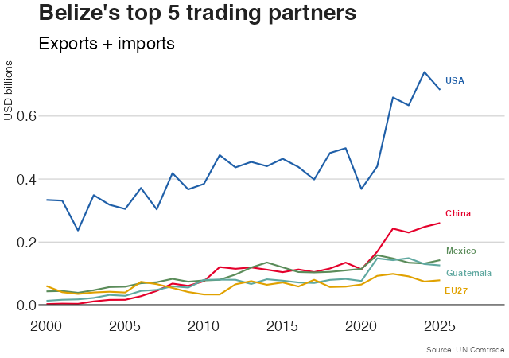

### Bolivia

Bolivia’s political landscape was transformed in the early 2000s by a wave of social mobilisation rooted in deep inequalities between the country’s largely mestizo and white urban elite and its majority indigenous population, which had been systematically excluded from political and economic power since independence. The so-called Water War of 2000 in Cochabamba, triggered by the privatisation of the city’s water supply, and the Gas War of 2003, which led to the resignation and flight into exile of President Gonzalo Sánchez de Lozada, marked the collapse of the traditional party system and opened the door for a new political force (Climate-Diplomacy 2020). Sánchez de Lozada, a US-educated mining magnate who had presided over a privatisation programme and oversaw a violent crackdown on protesters that left more than sixty people dead, was succeeded by his vice-president Carlos Mesa, who in turn resigned in 2005 under renewed popular pressure. Into this political vacuum stepped Evo Morales, a coca growers’ union leader from the Chapare region and a member of the Aymara people, who had built the Movement Toward Socialism (*Movimiento al Socialismo*, MAS) as a vehicle for Bolivia’s long-marginalised indigenous majority. In December 2005, Morales won the presidential election with 53.7 per cent of the vote in the first round, an outright majority unprecedented in Bolivian electoral history, becoming the country’s first indigenous head of state. He oversaw a new Constitution in 2009 that formally recognised Bolivia as a plurinational state and enshrined the rights of indigenous peoples. His governments pursued a programme of nationalisation of the hydrocarbons sector, expanded social programmes, and presided over a sustained reduction in poverty and inequality during a period of high commodity prices.

After nearly two decades of political dominance by the MAS, interrupted only briefly in 2019-2020 when Morales resigned and went into exile following disputed elections and military pressure, three presidential terms under his leadership and one by Luis Arce, the 2025 general elections marked a significant political shift with the election of Rodrigo Paz, son of former president Jaime Paz Zamora. Paz is a social conservative who advocates free market reforms and “capitalism for all.”

Bolivia is an ethnically diverse country in which roughly half the population is of indigenous origin, a group that had long formed the backbone of the MAS movement. However, internal divisions within the party led to a fragmentation of the MAS vote in the 2025 elections, as several younger candidates competed for that same electorate. Paz managed to attract a share of the indigenous vote through his running mate, Edmand Lara, a former police officer who had gained public prominence through his exposure of corruption on social media. This alliance proved decisive in the second round, as no other candidate had indigenous roots. It did not last long, however. Shortly after the election, Lara declared himself in opposition to the government.

Morales, who retains strong support among part of the population, presided over a period of economic growth and poverty reduction largely financed by high commodity prices, particularly hydrocarbons. This economic boom came to an abrupt end in 2023, when Bolivia entered a severe economic crisis characterised by a foreign exchange shortage, a sharp decline in international reserves, a structural fiscal deficit, and growing pressure on the national currency, the boliviano. Against this backdrop, the ruling MAS party became engulfed in an open power struggle between then-president Luis Arce and former president Morales, who was subsequently expelled from the party.

Despite a constitutional term limit on standing for re-election, Morales sought to advance his candidacy for the 2025 race, though his bid was ultimately rejected. He initially called for disruption of the electoral process, triggering sporadic violence across the country, before shifting to promoting a protest vote during the first-round campaign. He remains in hiding in the Chapare coca-growing region, where he commands strong social support, as multiple arrest warrants place him at risk of detention. He is facing a human-trafficking case related to allegations that he fathered a child with a fifteen-year-old girl during his presidency; having failed to appear at trial, a further arrest warrant was issued. The case dates to 2020, during the brief interim presidency of opposition leader Jeanine Áñez. Morales’ legal team has characterised it as political persecution (Ruvenal 2026). In October 2026, another charge was added as Bolivia’s attorney general announced an investigation into Morales’ alleged involvement in the murder and torture of European citizens in 2009 (Agence France-Presse 2026).

When Paz moved to slash long-standing fuel subsidies in order to reduce the budget deficit, widespread protests erupted, culminating in fifty days of highway blockades by labour unions and indigenous groups that brought the country to a standstill and pushed the government to the brink of collapse. The blockades had a cascading effect on the economy and society, with soaring prices putting basic goods out of reach for many Bolivians and hospitals facing shortages of medicines. The situation was brought to an end after Paz declared a state of emergency and authorised greater military involvement in restoring road access. Morales backed the protests, leading to a new arrest warrant issued in July 2026 for alleged armed uprising against the state. In light of the rising social discontent, Morales told journalists that he is contemplating a return to politics (Garrison 2026).

On the foreign policy front, Paz has overseen a significant reorientation of Bolivia towards Washington after nearly two decades of strained relations under Morales, who famously expelled the US ambassador, the Drug Enforcement Administration (DEA), and USAID. Paz lifted visa requirements for US citizens, welcomed back a US ambassador, secured multilateral financing including from the Washington-based Inter-American Development Bank, and invited the DEA to resume operations in the country. He has also courted US technology giants such as Amazon, Tesla, and Oracle to invest in Bolivia’s lithium and rare earth mineral industries (Swift and Bearak 2026).

The arrest of Fernando Cerimedo on 18 August in Bolivia, on charges of allegedly plotting to kill his girlfriend, Bolivian lawyer Nadia Beller, had far-reaching political consequences, given that he had served as a presidential adviser to Paz (Rogero 2026a). An Argentine political consultant known for his use of bot farms, Cerimedo had been involved with several of Latin America’s new wave of far-right leaders (Milei in Argentina, Kast in Chile, Bolsonaro in Brazil, and Asfura in Honduras). His former girlfriend began publicly releasing photographs and private communications, exposing the extent of his role and revealing that he had played a significantly larger part in Paz’s government than had been publicly acknowledged. Vice-president Lara added further pressure by asserting that Cerimedo had exercised real power and taken decisions within the Paz administration, and published unverified audio recordings attributed to conversations involving Cerimedo and members of Paz’s inner circle, including his wife. Beller also claimed to hold evidence of alleged irregular business dealings involving Paz and his family (Lissardy 2026).

In September 2026, the US Department of State designated Bolivia’s Attorney General Roger Mariaca for his alleged “involvement in significant corruption”, making Mariaca and his immediate family members generally ineligible for entry into the United States (United States Department of State 2026). Three days after the designation, Mariaca was arrested over alleged links to Uruguayan drug trafficker Sebastián Marset, who was extradited to the United States in March 2026 (EL DEBER 2026). The Public Prosecutor’s office denounced the arrest as illegal (Deutsche Welle 2026), while some observers have linked the arrest of Mariaca to his investigation into the activities of Cerimedo.

In July 2026, Bolivia reached a $1.9 billion staff-level agreement with the IMF, although the agreement still requires approval from the IMF’s Executive Board and Bolivia’s Congress. If approved, the deal would mark Bolivia’s first multi-year IMF arrangement since 2006 and the reforms associated with the programme are likely to have significant structural consequences and could generate further social unrest.

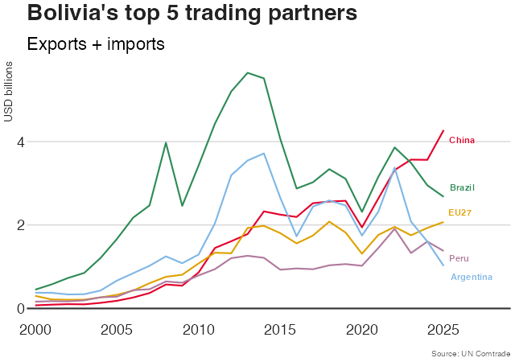

### Brazil

The election of Luiz Inácio Lula da Silva in 2002 brought the Workers’ Party (PT) to power. A former metalworker and trade-union leader, Lula was re-elected in 2006 and served until 2010. His governments combined macroeconomic stability with social policies, notably *Bolsa Família*, a cash-transfer programme for low-income families conditional on school attendance and health check-ups, alongside minimum-wage increases and measures to reduce poverty and inequality. Economic growth benefited from the commodities boom and rising Chinese demand for Brazilian exports. Lula’s administration also sought to strengthen Brazil’s international standing through South–South cooperation, multilateral diplomacy and the BRICS grouping. His successor, Dilma Rousseff, had served as minister of mines and energy and subsequently as Lula’s chief of staff. Elected in 2010 and re-elected in 2014, she continued the PT’s social and economic agenda but faced recession, mounting political opposition and the Lava Jato (Car Wash) investigation into corruption at the state oil company Petrobras, which implicated politicians across the governing coalition (Congressional Research Service 2016). Rousseff now heads the BRICS-founded New Development Bank (NDB).

Rousseff was removed from office in August 2016 following an impeachment trial in the Senate, which convicted her of violating fiscal and budgetary rules. However, the proceedings were deeply entangled with political manoeuvring. In December 2015, Eduardo Cunha, then president of the Chamber of Deputies and himself facing an ethics investigation over alleged corruption linked to Petrobras, reportedly threatened to accept the impeachment petition unless PT lawmakers on the Chamber’s ethics committee voted against investigating him. Rousseff’s removal also reflected the collapse of her political support amid a severe recession, with GDP contracting by more than 3% in both 2015 and 2016, unemployment reaching 11% and rising inflation. Mass street protests, hostile press coverage and growing isolation in Congress further weakened her position. Secret recordings published in May 2016 also showed Romero Jucá, a senior senator and ally of Rousseff’s vice-president, Michel Temer, appearing to link her removal to halting the Lava Jato investigation. Critics further interpreted the financial markets’ positive reaction to the progress of impeachment as evidence of business and financial circles’ preference for a change of government. Rousseff denounced her impeachment as a parliamentary coup, while her opponents maintained that the fiscal violations warranted her dismissal. Although the process followed constitutional procedures, its political legitimacy remained contested. Temer, from the Brazilian Democratic Movement Party (PMDB, now MDB), succeeded her and pursued a more market-oriented agenda, including spending restraints and labour-market reform (Jiménez Barca 2016; Watts and Bowater 2016).

The political crisis also exposed the increasingly contentious relationship between electoral competition, anti-corruption investigations and the judiciary. In the 2018 presidential election, the PT initially nominated former President Lula da Silva, who was the clear favourite in the polls. However, the party was forced to replace him at the last minute with Fernando Haddad, a former mayor of São Paulo, after the electoral court barred Lula, who was in prison following a corruption conviction that was later annulled. Lula spent 580 days in prison, while Haddad, hindered by a late start and his low national profile, eventually lost the runoff to Jair Bolsonaro, a former army captain who campaigned on an anti-establishment, socially conservative and strongly anti-PT platform.

In 2021, the Supreme Federal Court annulled Lula’s convictions on jurisdictional grounds, ruling that the cases should not have been tried by the court in Curitiba, which restored his political rights. In a separate decision, a panel of the Court found that former judge Sérgio Moro had acted with bias in the proceedings against Lula. These judgments undermined the validity of the convictions and reinforced concerns about the political contamination of the anti-corruption campaign (Associated Press 2021; Folha de S.Paulo 2021; The Intercept Brasil 2019).

Bolsonaro’s presidency, from 2019 to 2022, marked a sharp ideological shift. His administration promoted pension reform, privatisation and a reduced role for the state in the economy, while advancing socially conservative positions. Environmental protection weakened, and deforestation in the Amazon increased. Bolsonaro also defended Brazil’s military dictatorship and repeatedly challenged democratic institutions, particularly the electoral system. In foreign policy, he cultivated a close ideological relationship with Donald Trump during the latter’s first presidency. Yet this alignment had important limits. Bolsonaro’s rhetoric could be hostile towards Beijing, but China remained indispensable to Brazil’s export economy, particularly for soybeans, beef and iron ore. The contradiction between political affinity with Washington and economic dependence on China exposed a structural constraint on any attempt to reorient Brazilian foreign policy too sharply towards the United States (Bolle 2026; D. Phillips 2019; T. Phillips and Phillips 2018).

Lula returned to the presidency in January 2023 after defeating Bolsonaro in the October 2022 election. Bolsonaro refused to accept the result, and on 8 January 2023 his supporters stormed the presidential palace, Congress and Supreme Court buildings in Brasília in an attempt to create conditions for overturning Lula’s victory. In September 2025, Bolsonaro was convicted by the Supreme Federal Court of organising a coup and attempting to violently abolish democracy, among other crimes, and sentenced to 27 years and three months in prison. He was subsequently placed under house arrest for medical reasons (Brito, Magalhães, and Andreoni 2025).

Lula’s third presidency sought to revive social redistribution, strengthen domestic industry and restore Brazil’s international profile. His government has pursued closer diplomatic and economic relations with China, Brazil’s largest trading partner since 2009. Beijing has also expanded its presence in sectors such as electric vehicles, renewable energy, telecommunications and industrial technology. This partnership offers Brazil significant markets and investment, but also creates tensions with Lula’s objective of reindustrialising the economy and developing domestic technological capacity. Chinese companies are increasingly competing with Brazilian producers, while Brazil’s reliance on commodity exports makes it vulnerable to changes in Chinese demand (Bolle 2026).

Relations between Lula’s government and the Trump administration have remained pragmatic but fraught with tensions. In July 2025, Washington announced tariffs reaching 50% on many Brazilian imports, linking the measures in part to the prosecution of Bolsonaro. The United States also sanctioned Supreme Federal Court Justice Alexandre de Moraes, who had played a prominent role in proceedings against the former president. Lula rejected the pressure as interference in Brazil’s sovereignty and the independence of its judiciary.

In 2026, the dispute extended into the presidential campaign. The Trump administration designated Brazil’s two dominant criminal organisations, the *Primeiro Comando da Capital* (PCC) and *Comando Vermelho*, as terrorist organisations. The designations, announced in the middle of the campaign, politicised the issue of public security, and their timing raised questions about Washington’s motives, given that the United States had not previously treated these groups as such a threat. There is also no evidence that *Comando Vermelho* had a significant presence in the United States or was substantially involved in its financial system. The trafficking routes dominated by these groups and the markets in which they operated were primarily oriented towards Europe rather than the United States (Dudley and Newton 2026). Flávio Bolsonaro, Jair Bolsonaro’s son and Lula’s principal challenger in the 2026 election, used the issue to accuse the incumbent of being weak on crime (EL PAÍS 2025; T. Phillips 2026; Rogero 2026b; Stargardter 2026).

A related controversy concerned the influence of American technology companies over Brazil’s democratic process. During the 2026 campaign, Lula and his allies accused Meta, which owns Facebook, Instagram and WhatsApp, of favouring Flávio Bolsonaro. According to reports based on internal communications, Meta employees acknowledged that restrictions had hindered Lula’s Instagram accounts during the election (Royo Gual 2026; Teles 2026).

The presidential runoff on 25 October 2026 provided a further test of Brazil’s political polarisation and its international orientation. Lula defeated Flávio Bolsonaro with 51.79% of valid votes against 48.21%, becoming the first candidate since the restoration of direct presidential elections in 1989 to win a runoff after finishing second in the first round. Lula’s campaign overhauled his social media strategy, while his government introduced a series of popular economic and social measures in the run-up to the election. These included a 15% increase in *Bolsa Família* payments, a new household debt-renegotiation programme, and a constitutional amendment reducing the maximum working week from 44 to 40 hours without cutting pay. His victory secured a fourth term and represented a setback for Trump’s efforts to strengthen the position of ideologically aligned governments across Latin America. Flávio initially rejected the result and called for the election to be annulled, echoing his father’s refusal to accept defeat in 2022. Just two days after his defeat he left Brazil for the United States amid an investigation into alleged money laundering (Agencias 2026; Galarraga Gortázar 2026).

Trump openly criticised the Brazilian election, telling reporters that it “looked terrible” and resembled “another rigged election”. He also said he would be willing to receive Flávio Bolsonaro and his family in the United States after their departure from Brazil (Agencias 2026; Ionova, Ellick, and Nicas 2026). In his victory speech, Lula rejected US ambitions in the Western Hemisphere and declared that Brazil would not be “anyone’s backyard”. He also rejected placing Brazil within a bipolar framework dominated by rivalry between the United States and China, emphasising the country’s determination to pursue an autonomous path. This ambition extends to technology, with Lula declaring, “I do not want to remain dependent on Chinese or American artificial intelligence; I want to create a Brazilian one” (Le Grand Continent 2026b). Lula’s fourth term will thus begin with a clear diplomatic orientation but difficult domestic constraints, as he faces a hostile Congress, persistent economic pressures, demands for improved public security and continuing disputes over the legitimacy of public institutions (T. Phillips and Rogero 2026).

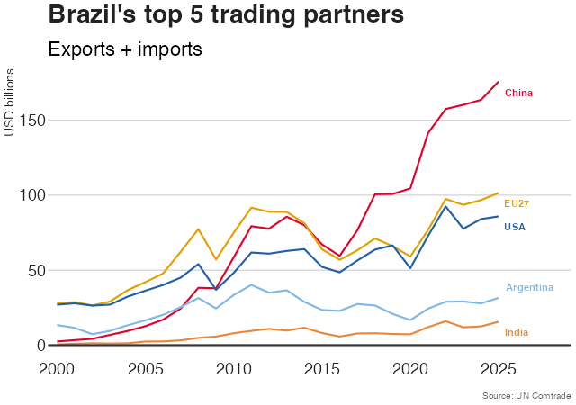

### Chile

Chile’s recent political trajectory has been marked by persistent anti-incumbency. The last time a president handed power to a successor from the same political camp was in 2006, when Ricardo Lagos of the centre-left Concertación was succeeded by fellow coalition member Michelle Bachelet. Every presidential election since has resulted in a change of political camp: Sebastián Piñera’s centre-right government replaced Bachelet’s in 2010, she returned to office in 2014, Piñera won again in 2018, and left-wing Gabriel Boric defeated him in 2021 before losing to right-wing José Antonio Kast in 2025. This recurring rejection of the governing camp reflects widespread disenchantment with political parties and distrust in institutions, alongside shifting concerns over inequality, security, migration and economic performance (Rivas Molina and Sanhueza 2025).

The mass protests of 2019, driven by grievances over inequality and the cost of living, prompted a process to replace the Constitution inherited from the Pinochet dictatorship. In the October 2020 referendum, 78 per cent voted to begin drafting a new constitution. Boric, a left-wing candidate who drew support from the protest movement, defeated Kast in the 2021 presidential election. However, the draft produced by a predominantly left-wing constitutional convention was rejected by 62 per cent of voters in September 2022. A second proposal, drawn up by a conservative-dominated body, was also rejected in December 2023, this time by 56 per cent. The rejection of both proposals underscored the diffulty of building a consensus on constitutional change and left the country’s underlying political divisions unresolved. Against a backdrop of continuing concerns about crime, migration and economic performance, Kast defeated the governing coalition’s candidate, Jeannette Jara, with 58 per cent of the vote in December 2025. His victory continued the pattern of incumbent defeat while also fitting the broader rightward shift seen across Latin America (Montes 2020, 2023; Rivas Molina and Montes 2022; Rivas Molina, Montes, and Laborde 2021; Villegas and Cambero 2025)

The closer alignment between Washington and Santiago under Kast contrasts with some of the discrepancies that characterised relations under the Boric administration. In February 2026, shortly before Kast took office, the Trump administration revoked the visas of three Chilean officials involved in the assessment of a proposed undersea fibre-optic cable linking Chile to Hong Kong, arguing that the project compromised critical telecommunications infrastructure and regional security. US Ambassador to Chile Brandon Judd defended the measure, saying that visa sanctions “were not meant to punish, but to change behaviour” (Rodríguez Mega et al. 2026). The episode illustrates the extent to which the Trump administration has used visa restrictions as an instrument of foreign-policy pressure in the region, particularly in relation to China’s growing presence in Latin America.

Under Kast, Chile has subsequently moved closer to Washington. In September 2026, his government joined Trump’s “Shield of the Americas”, a regional initiative presented by Washington as a framework for cooperation on security but which also encompasses economic and multilateral coordination. The initiative has provoked a significant political debate in Chile. Former presidents Michelle Bachelet and Gabriel Boric jointly called on the Kast government to reconsider Chile’s participation, arguing that Chile should not be forced to choose sides in the current geopolitical context (Sanhueza 2026).

Kast’s foreign-policy orientation also reflects his ideological proximity to other right-wing governments in the region. On 3 September 2026, Santiago hosted the fifth regional meeting of the Madrid Forum, which presents itself as a network of American and European right-wing forces and has become an important meeting place for the right in Latin America. Argentine President Javier Milei was one of the event’s main speakers. In his speech, Milei referred to the overthrow of Salvador Allende, Chile’s democratically elected socialist president, as the beginning of a period of stability and economic growth under Augusto Pinochet, arguing that Chile subsequently became the envy of the region economically (Forti 2026). His remarks drew criticism in Chile not only from the opposition but also from within Kast’s governing coalition. While Kast’s Republican Party endorsed Milei’s comments, they were rejected by the centre-right Independent Democratic Union (UDI) (Forti 2026).

Kast’s presidency represents both a significant shift in Chile’s political orientation and the continuation of its long-standing pattern of anti-incumbency. His early decline in popularity has exposed the gap between his campaign promises and the difficulties of governing. By October 2026, his approval rating had fallen to 27 per cent, while 64 per cent disapproved of his performance and 82 per cent said the government had fallen short of their expectations. The decline has extended beyond opposition voters to include people who voted for Kast and other right-wing voters. Having campaigned on an “emergency government” that would quickly revive the economy and impose tougher controls on crime and irregular migration, he has yet to deliver the improvements voters expected. Fiscal adjustments, including cuts affecting health, education, science, culture and social programmes, have added to dissatisfaction amid rising living costs and economic stagnation. His government has also struggled to secure legislative agreements, while ministerial missteps have weakened confidence in its competence (Andrade 2026; Dannemann 2026). If this trend continues, Kast could become the latest president whose political camp is rejected at the next election.

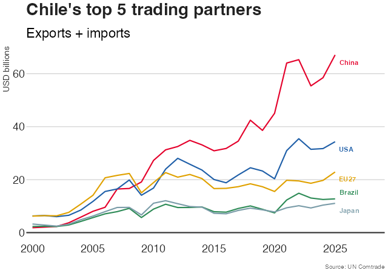

### Colombia

Colombian politics since 2000 has been dominated by right and centre-right governments with the election of Gustavo Petro in 2022 marking a historic break with this pattern. Álvaro Uribe, elected president in 2002 and re-elected in 2006, built a powerful right-wing political movement around a hard-line security agenda and deep hostility towards the guerrillas, in particular the Revolutionary Armed Forces of Colombia (FARC). His two governments were closely aligned with Washington during the Bush era, and implemented market-friendly economic policies.

His successor, Juan Manuel Santos, had served as Uribe’s defence minister, initially seen as his continuity candidate, subsequently broke with him over negotiations with the FARC. He negotiated and signed the 2016 peace agreement with FARC, gaining the Nobel Peace Prize for it, but the agreement was ultimately rejected by voters in a referendum (50.2% against, 49.8% in favour) though a renegotiated version was subsequently ratified by Congress.

Iván Duque, elected in 2018 with Uribe’s support, represented a return to a more confrontational approach to the peace process. The election of Petro, a former M-19 guerrilla and leader of the left-wing Historic Pact coalition, therefore marks a a watershed moment for Colombia as he became its first left-wing president, partly due to widespread discontent with inequality, social exclusion and the established political elite (Canelas 2022; Parkin Daniels and Bolaños 2022).

Petro pledged sweeping social transformation, but his reform agenda was repeatedly slowed or blocked by a fragmented Congress, judicial scrutiny and institutional resistance. His flagship *Paz Total* policy, aimed at negotiating with armed groups, produced limited progress, while violence and the territorial influence of illegal armed actors remained serious concerns. In October 2025, the Trump administration imposed sanctions on Petro, his wife, his son and a close associate, accusing them of allegedly permitting drug cartels to operate with impunity (U.S. Department of the Treasury 2025).

The 2026 presidential election brought a striking change in political direction with the victory of Abelardo De La Espriella, who defeated left-wing candidate Iván Cepeda in the June run-off. De La Espriella is a wealthy criminal defence lawyer who had never held elected office and presented himself as an anti-establishment outsider. His rise is part of a broader regional trend towards personalist, hard-right political movements, but it was not simply a return to the traditional Colombian right. He rejected the established parties and portrayed himself as a political outsider, while advocating a security-first agenda inspired by Nayib Bukele in El Salvador and a radical reduction in the size of the state modelled on Javier Milei in Argentina. His outsider image was nevertheless complicated by the public endorsement he received from former president Álvaro Uribe after the first round. De La Espriella also received Donald Trump’s endorsement ahead of the run-off, which he presented as an opportunity to reset relations with Washington (Correal 2026; Martín 2026; Reuters 2026c).

De La Espriella’s programme combines an aggressive security agenda with market-oriented economic policies. He promised to end negotiations with armed groups, build ten mega-prisons, resume aerial eradication of coca crops, expand oil and gas exploration and abolish the wealth tax. He also pledged to reduce the size of the state by as much as 40 per cent (Epoch Times Español 2026; Stacey 2026b). On taking office on 7 August 2026, he announced that Colombia would join Trump’s *Shield of the Americas*, a regional security initiative focused on organised crime and drug trafficking. He delivered his inaugural address at the Pichincha Battalion in Cali directly to military and police commanders, reinforcing the centrality of security to his administration’s agenda.

There is, however, a contradiction between De La Espriella’s promise of radical austerity, his criticism towards Petro for overspending and his own government’s first budget proposal. The draft 2027 budget submitted to Congress was 10 per cent larger than the proposal presented by Petro’s administration (Freixes 2026; Quintero 2026). De La Espriella also built a reputation in Miami representing high-profile Colombian clients, many of them charged with drug trafficking and corruption or linked to right-wing paramilitaries, the kind of clientele he now vows to pursue as president.

The foreign-policy shift has been most visible in relations with the United States. De La Espriella spent almost a decade in Miami and became a naturalised US citizen in 2023, while cultivating ties with Republican politicians. His relationship with Washington predates his presidency as he had donated to the campaigns of Florida Republican congresswoman María Elvira Salazar, who also publicly supported his presidential bid. Trump’s endorsement during the Colombian campaign and the new government’s decision to join the *Shield of the Americas* have since been followed by a closer security partnership. On 7 August, the US administration announced plans to provide Colombia with a $1 billion security assistance package, signalling closer alignment in bilateral relations after the repeated confrontations between Trump and Petro (Stacey 2026a; U.S. Department of State, Office of the Spokesperson 2026). The shift in bilateral relations extends to Colombia’s position on the International Criminal Court. Colombia has been a party to the Rome Statute since November 2002. In May 2026, shortly before the transfer of power, the ICC Office of the Prosecutor and Colombian authorities reaffirmed their commitment to cooperation and complementarity, building on the agreement signed in 2021 (International Criminal Court 2026). Since De La Espriella took office, however, his government has signalled a markedly different approach. It withdrew Colombia’s candidate for an ICC judgeship, while the president’s administration has advocated the possibility of withdrawing from the Rome Statute. The shift has unfolded amid explicit US pressure as Pete Hegseth, the US secretary of war, urged countries participating in the *Shield of the Americas* to leave the ICC, while Washington has pursued a broader campaign against the Court (Garcés 2026; Parada Lugo 2026).

A related change concerns Colombia’s position before the International Court of Justice (ICJ), not to be confused with the ICC. Under Petro, Colombia had intervened in South Africa’s case against Israel under the Genocide Convention, in which South Africa alleges that Israel’s conduct in Gaza violates the Convention. On 22 September 2026, the De La Espriella government formally withdrew Colombia’s declaration of intervention in that case (Ministerio de Relaciones Exteriores de Colombia 2026). This was part of a broader realignment with Israel and a departure from Petro’s approach to the Gaza war.

Petro had broken diplomatic relations with Israel in 2024 and halted Colombian coal exports to the country in protest against its military campaign in Gaza. De La Espriella reversed this policy, restored diplomatic relations and recognised Israeli sovereignty over the occupied Golan Heights, making Colombia only the second country in the world, after the United States, to officially recognise Israeli sovereignty over the occupied Golan Heights, breaking with the prevailing international position that the territory remains Syrian. On 14 October 2026, Colombia opened its embassy in Jerusalem and restored its free-trade agreement with Israel, reversing another element of the previous government’s policy (Pita 2026; Reuters 2026a).

The alignment with the United States and Israel was highly visible during the response to the devastating earthquake that struck Colombia on 10 August, three days after De La Espriella took office. Although several countries offered assistance, the foreign search-and-rescue teams initially admitted by Bogotá came from the United States, Israel, Ecuador and El Salvador, while teams offered by countries including Mexico and Brazil were not initially accepted. The selective admission of search-and-rescue teams offered a striking early illustration of the new government’s foreign-policy priorities.

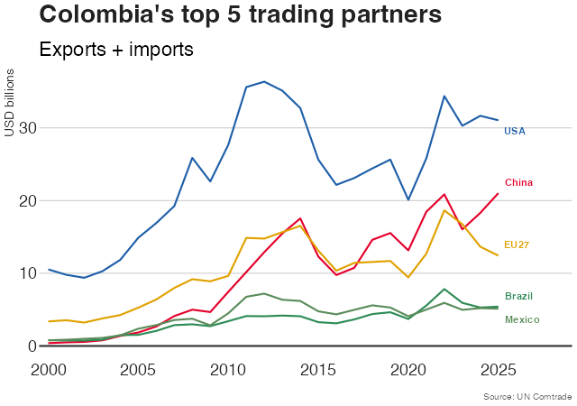

### Costa Rica

Costa Rica’s political trajectory since 2000 has been marked by the breakdown of its traditional two-party system and the subsequent emergence of increasingly fragmented and personalist electoral competition. For decades, the centre-left National Liberation Party (PLN) and the centre-right Social Christian Unity Party (PUSC) dominated politics. The 2002 election disrupted this arrangement, as the newly established Citizen Action Party (PAC) emerged as a significant challenger. Corruption scandals involving former presidents and declining trust in the established parties contributed to a realignment that marked the beginning of a gradual transition towards a more fragmented multiparty system. The divide between competing economic models became particularly visible during the presidency of Óscar Arias (2006–2010), whose government pursued closer economic integration with the United States through the Dominican Republic–Central America–United States Free Trade Agreement (CAFTA-DR). The agreement was approved by a narrow majority of 51.6 per cent in a highly polarised referendum in October 2007 (Perelló and Navia 2021; Willis and Seiz 2012).

Arias’s presidency also brought a major shift in Costa Rica’s relations with China. In June 2007, his government ended nearly six decades of diplomatic relations with Taiwan and established formal ties with the People’s Republic of China, presenting the decision as economic pragmatism. Beijing subsequently provided development assistance and financed infrastructure projects, and the two countries negotiated a free-trade agreement that entered into force in 2011. The switch strengthened Costa Rica’s economic engagement with China without displacing the United States as its principal economic and strategic partner (Feigenblatt 2021; Watts 2007).

The PAC won the presidency in 2014 and 2018 under Luis Guillermo Solís and Carlos Alvarado respectively, but its electoral collapse in 2022 exposed the extent of public dissatisfaction with the established parties. Rodrigo Chaves, a former World Bank economist with no previous elected office, won on an anti-establishment platform. His victory reflected a wider shift towards personalist politics and electoral volatility rather than a simple ideological realignment (Cuitiño Burone 2023).

The February 2026 presidential and legislative elections marked a continuation of Chaves’s political project. Constitutionally barred from seeking immediate re-election, he supported his former Minister of Planning, Laura Fernández Delgado, who ran for the newly created Sovereign People’s Party (PPSO). Fernández won 48.5 per cent of the vote in the first round, comfortably exceeding the 40 per cent threshold for outright victory (European Union Election Expert Mission 2026). Costa Rica thus became one of the relatively few cases in the region in recent years in which the governing political movement retained the presidency. The PPSO also won 31 of the 57 seats in the Legislative Assembly, giving it a simple majority and the largest parliamentary bloc since 1982, although short of the 38 seats required for a two-thirds supermajority (Villegas and Murillo 2026).

During his presidency, Chaves adopted an increasingly confrontational stance towards other branches of government and oversight institutions, repeatedly accusing the Legislative Assembly, the judiciary, the Prosecutor General’s Office, the Comptroller’s Office and, most notably, the Supreme Electoral Tribunal (TSE) of obstructing his government’s policies. This rhetoric contributed to declining confidence in public institutions, especially among PPSO supporters (European Union Election Expert Mission 2026). Fernández has pledged to continue Chaves’s hard-line approach to security as Costa Rica faces a severe deterioration in public safety, including record levels of homicide and drug-related violence, which have become the main concern of the country’s 3.7 million voters. The appointment of Chaves as both Minister of the Presidency and Minister of Finance in Fernández’s administration further underscores the continuity between the two governments. However, it has also attracted criticism, as it enables the former president to retain a central role in government while shielding him from prosecution amid ongoing corruption allegations (Córdoba 2026a).

Foreign policy under Chaves marked a more pronounced departure from Costa Rica’s traditional diplomatic posture. The country abolished its armed forces in 1948 and formally proclaimed a policy of “perpetual, active and unarmed neutrality” in 1983. Although this principle has never meant complete detachment from Washington, successive governments generally emphasised multilateralism, peaceful dispute settlement and human rights. Chaves increasingly aligned his government with the Trump administration, including by accepting 25 third-country deportees per week from the United States, closing Costa Rica’s embassy in Cuba and designating Hamas, Hezbollah, the Houthis and Iran’s Islamic Revolutionary Guard Corps as terrorist organisations (Córdoba 2026a). His government has also been accused of lobbying Washington to revoke the visas of the board members of a critical newspaper, La Nación, a step the US administration took in May without further explanation (Córdoba 2026b). In March 2026, Chaves’ outgoing administration joined Trump’s Shield of the Americas (Quesada Webb 2026).

Relations with China have become more contentious despite the commercial links established since 2007. In August 2023, Chaves issued a decree regulating participation in Costa Rica’s 5G telecommunications network through requirements tied to the Budapest Convention on Cybercrime, effectively excluding Huawei and other companies from countries that had not joined the convention. The directive came shortly after a visit by Laura Richardson, then head of US Southern Command, who questioned growing Chinese investment in Latin American infrastructure, including ports and 5G networks. The Chinese embassy criticised the restrictions as discriminatory and warned that they could undermine bilateral economic ties (Reuters 2023).

Relations with the European Union offer a further dimension to Costa Rica’s external partnerships. The EU and Central America signed an Association Agreement in 2012, with its trade pillar provisionally applied to Costa Rica from 2013. The full agreement entered into force on 1 May 2024, strengthening political dialogue and cooperation alongside trade. The EU has consequently become an important partner for Costa Rica in trade, investment and institutional cooperation, complementing its economic relationship with the United States and China (European External Action Service 2024). Costa Rica’s nomination of Rebeca Grynspan, a former vice-president who has led UNCTAD, for the next UN Secretary-General is a further sign of its continuing interest in multilateral diplomacy, and Fernández has publicly reaffirmed her government’s support for the candidacy.

Costa Rica’s recent trajectory therefore combines domestic political change with a significant shift in diplomatic emphasis that breaks with its tradition of neutrality. Its party system has moved from a relatively stable two-party arrangement towards more fragmented and personalist competition, while the Chaves–Fernández governments have adopted a harder security agenda and closer alignment with Washington.

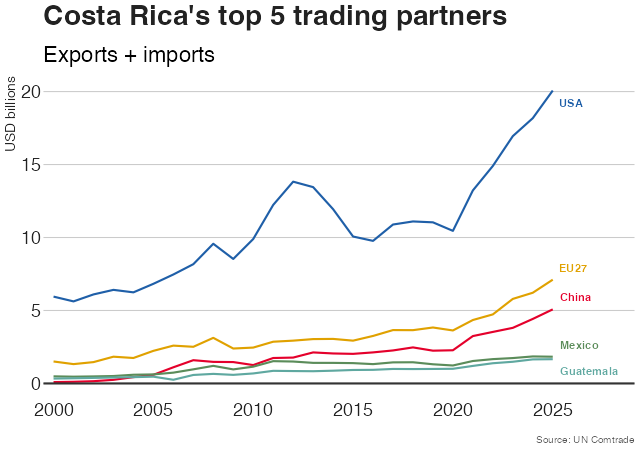

### Cuba

Since the beginning of 2026, Washington has imposed an oil blockade on Havana alongside intensified economic sanctions. Secretary of State Marco Rubio, the son of Cuban immigrants who has made toppling Cuba’s communist government a personal project, described the measures as “the strongest sanctions in the history” of bilateral relations (Colomé 2026). Heavily reliant on imported oil, Cuba previously received most of its supplies from Venezuela. Those shipments stopped after the United States captured Venezuelan President Nicolás Maduro in January 2026, and no Venezuelan oil has reached the island since. The resulting energy shortage has plunged Cuba into repeated nationwide blackouts. With the exception of the Russian tanker *Anatoly Kolodkin*, which delivered oil to Cuba in March, no significant alternative supplies have reached the island. Even countries sympathetic to Cuba, including Mexico and Brazil, have been reluctant to ship fuel because of the risk of retaliation and sanctions from Washington. The US administration has explicitly threatened tariffs against countries that provide oil to Cuba (Colomé 2026).

The effects have extended beyond energy. Shipping containers carrying food, medicine and other goods bound for Cuba have been stranded throughout the Caribbean after the main shipping companies stopped serving the island for fear of sanctions. According to the Cuban ambassador to the United Nations in Geneva, more than 7,000 containers have been affected. The lack of medicine and rising food prices have created what has been described as the most severe humanitarian crisis on the island since the 1959 revolution (Augustin and Robles 2026).

In September 2026, the US Coast Guard intercepted the *Grace*, a vessel that US authorities said was carrying fuel to Cuba, in violation of international law (Adams 2026). Cuban Foreign Minister, Bruno Rodríguez, denounced the US blockade at the United Nations General Assembly as an act of war (Adams 2026). Cuba is producing some fuel domestically, but nowhere near enough to meet its needs. At the same time, the limited oil that does reach the island is increasingly being imported by private businesses from the United States. As a result, US exports to Cuba have risen sharply: from just over $416.5 million in 2025 to almost $700 million in 2026, an increase of around 61% (Colomé 2026).

The political objective of the policy is explicit. President Donald Trump stated at the United Nations General Assembly that his administration was “seeking a fundamental change in the situation in Cuba” (Trump 2026). The combination of cutting off Cuba’s traditional sources of fuel, deterring third countries from supplying the island and allowing selected private-sector imports from the United States is placing severe pressure on the Cuban economy while increasing the role of US-linked private commerce.

As a result of the economic crisis, Cuba has experienced the largest outflow of people in its history since 2020. Estimates range from 13% of the population according to official figures to as much as 25% according to independent estimates, representing approximately 1.6 to 2.75 million people (Council on Foreign Relations 2026a). What began as a response to Cuba’s post-pandemic economic collapse has evolved into a crisis of its own, as public services are increasingly affected by the loss of personnel, from teachers and nurses to doctors. Initially, the United States continued to offer relatively generous pathways to legal residency to newly arrived Cubans, but this changed under the second Trump administration, which ultimately redirected migration flows. Hundreds of thousands of Cubans applied for Spanish citizenship, while many thousands more travelled to countries such as Brazil and Uruguay (Council on Foreign Relations 2026a).

During the first half of 2026, a US military intervention in Cuba appeared increasingly possible. Subsequent backchannel talks between Havana and Washington offered a potential way out of the crisis, reportedly involving the removal of President Miguel Díaz-Canel. The policy now appears to have shifted, however, with Secretary of State Rubio stating that the Cuban regime could survive into 2028 and beyond (Freeman 2026a). One possibility is that Washington is deliberately maintaining economic pressure to strengthen its position in future negotiations or to further weaken the Cuban military in preparation for a possible intervention. Another is that, with the United States preoccupied with Iran and managing the situation in Venezuela, Cuba has simply become a less immediate priority.

### Ecuador

Ecuador’s political trajectory since 2000 has been marked by instability, followed by the profound realignment brought about by the left-wing Rafael Correa after his election in 2006, and then by a pendulum swing in the opposite direction with the election of the conservative former banker Guillermo Lasso in 2021 and, subsequently, Daniel Noboa in 2023. Over the same period, the country went from being one of the region’s most peaceful to one of its most violent. Ecuador entered the century amid a severe economic and political crisis that culminated in the removal of President Jamil Mahuad in January 2000. Lucio Gutiérrez, a former army colonel who had taken part in the uprising against Mahuad, was elected president in 2002 but was himself removed following mass protests in 2005. By then, Ecuador had experienced years of exceptional instability and widespread distrust of its political establishment (Aznárez 2000; Creamer 2005).

The election of Rafael Correa in 2006 transformed Ecuadorian politics and formed part of the Pink Tide, the wave of left-wing governments that came to power across Latin America. His Citizens’ Revolution (*Revolución Ciudadana*) dominated the country for a decade, expanding social spending and the role of the state while strengthening the presidency and centralising political power. A new constitution adopted in 2008 further consolidated his project. Correa also pursued a more independent foreign policy, distancing Ecuador from Washington and strengthening relations with other left-wing governments in the region and with China. Although he left office in 2017, Correa remains the central political reference point in Ecuador, and politics has since been largely structured around the divide between correísmo and its opponents (Rivas Molina 2021b).

Correa’s chosen successor, Lenín Moreno, won the presidency in 2017 but rapidly broke with his former ally and moved Ecuador away from Correa’s political project. Correa, meanwhile, became increasingly isolated and remained abroad, in Belgium, his wife’s home country, after corruption convictions that he has consistently described as politically motivated. The split within the Citizens’ Revolution fragmented the Ecuadorian left and paved the way for Lasso’s election in 2021 (España 2017; España and Manetto 2021; Rivas Molina 2021a).

Lasso’s presidency was marked by political paralysis, a fragmented legislature, deteriorating security and widespread corruption. Facing an impeachment process in 2023, he invoked the constitutional mechanism known as *muerte cruzada*, dissolving the National Assembly and calling early elections. The resulting contest once again demonstrated Correa’s enduring influence. Luisa González, one of his closest protégées and the candidate of the *Revolución Ciudadana*, won the first round and faced Daniel Noboa in the run-off. Noboa, the son of Álvaro Noboa, one of Ecuador’s wealthiest businessmen, and a dual US-Ecuadorian citizen, prevailed with 51.83 % of the vote against González’s 48.17 %. He became president in November 2023 at the age of 35, Ecuador’s youngest elected president, but only for the remaining 18 months of Lasso’s term (Dressler and Wolff 2024).

Noboa’s victory did not end the divide between correísmo and anti-correísmo. He faced González again in the 2025 presidential election and defeated her a second time, this time by a considerably larger margin (55.63% against 44.37%), securing a full four-year term. González nevertheless remained the country’s main opposition figure and the most prominent representative of the movement founded by Correa. Noboa has pursued a strongly militarised response to Ecuador’s acute security crisis. In January 2024, he declared an “internal armed conflict” against criminal groups and deployed the armed forces extensively in domestic security operations. The strategy initially contributed to a reduction in homicides, but Ecuador remains one of the region’s most violent countries and the longer-term security situation is highly unstable. The militarisation of public security has also raised serious human-rights concerns (Amnesty International 2026).

At the same time, Noboa has moved Ecuador closer to the United States, particularly on drug trafficking and organised crime. Ecuador joined Trump’s Shield of the Americas, a regional security initiative, and in September 2026 the United States designated the *Los Tiguerones* gang as a terrorist organisation (The Guardian 2026). Compared with the Correa era, Noboa’s presidency therefore marks a clear turn towards Washington on security.

Despite Noboa’s close political and security relationship with Washington, Ecuador remains economically tied to China. Beijing has financed major infrastructure projects and is a leading destination for Ecuadorian exports, particularly shrimp. In August 2026, Noboa made his first state visit to China, meeting President Xi Jinping and other senior leaders and signing new agreements on trade, investment and cooperation. The visit illustrated the limits of any geopolitical realignment, since Ecuador can move closer to Washington on security while continuing to deepen its economic relationship with China.

Domestically, however, political tensions have sharpened considerably in 2026. In October, authorities arrested Luisa González, Noboa’s opponent in both the 2023 and 2025 presidential elections, as part of an investigation into alleged irregularities in the financing of her 2023 campaign. González and the *Revolución Ciudadana* rejected the accusations and described the proceedings as politically motivated. The arrest followed earlier electoral proceedings that had already restricted the participation of the correísta movement and other opposition candidates. In a letter to the US Secretary of State, members of the US Congress warned of what they described as a coordinated effort to remove political opposition from Ecuador’s electoral process. They also criticised the Trump administration’s increasingly close security relationship with Noboa’s government and its support for an overly militarised response to the crisis under the banner of a “war on narcoterror” (García 2026; Mella 2026; Valencia 2026).

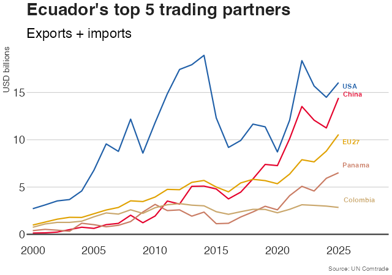

### El Salvador

Nayib Bukele became president at the age of 37 in 2019 and was re-elected by a landslide in 2024 (Kitroeff 2024). His presidency has been dominated by his campaign against gang violence, which has made him one of Latin America’s most popular leaders, but also by the concentration of political power and the erosion of civil liberties.

His government gained a legislative supermajority in 2021, allowing Bukele and his *Nuevas Ideas* party to exert increasing control over the legislature, judiciary and other state institutions. The Supreme Court, whose judges had been appointed by the legislature after Bukele’s party removed the previous magistrates, ruled in 2021 that he could seek a second consecutive term, despite the previous constitutional prohibition (BBC News Mundo 2021). In 2025, the legislature subsequently abolished presidential term limits, allowing Bukele to seek indefinite re-election.

The turning point of the security crackdown came in March 2022, when a surge in gang violence prompted the government to declare a state of emergency that has remained in force ever since. The measure greatly expanded the powers of the police and armed forces and enabled mass arrests (Abi-Habib and Avelar 2022). More than 90,000 people have since been detained, bringing the prison population to approximately 120,000 and giving El Salvador one of the world’s highest incarceration rates (Wagner 2026). The government subsequently introduced tougher penalties for gang membership, removed limits on pretrial detention and authorised mass trials in which up to 900 defendants can be prosecuted together when allegedly linked to the same criminal organisation (Wagner 2026). Human rights organisations have documented widespread due-process violations and cases of people being detained without credible evidence. In late 2024, Bukele acknowledged that 8,000 people detained during the crackdown had subsequently been released because they were innocent (swissinfo 2024). Human rights groups have said that this number is much higher and estimate that roughly 30,000 innocent people were arrested (Wagner 2026).

The crackdown has nevertheless produced a dramatic decline in violent crime, transforming El Salvador from one of the world’s most dangerous countries into one of the safest. El Salvador’s homicide rate, which stood at 103 per 100,000 inhabitants in 2015, fell steadily over the following decade to 1.3 in 2025 (Statista Research Department 2026). The government’s security policies have enjoyed substantial domestic support, despite continuing criticism over their human-rights consequences.

More than four years after the mass arrests began, detainees are now being brought to trial in large groups. Human Rights Watch has documented serious deficiencies in these proceedings, including restrictions on the right to defence, violations of international human rights standards and the near-universal conviction of defendants in mass trials (Human Rights Watch 2026a).

In terms of foreign policy, under former Salvadoran president Salvador Sánchez Cerén (2014–2019), El Salvador broke off relations with Taiwan in 2018 and recognised the People’s Republic of China. One of Beijing’s gifts to the country in exchange for its support was the US$54 million National Library in the historic centre of San Salvador. Inaugurated in November 2023, the modern building was promoted by Bukele as a legacy for future generations, as well as a symbol of his government’s achievements (Vigna 2024).

Bukele has also developed a particularly close relationship with the United States under Donald Trump. In February 2025, he offered to accept people deported from the United States, including alleged criminals from third countries, for detention in Salvadoran prisons in return for a fee. In March 2025, the United States transferred 238 Venezuelans alleged to be members of the Venezuelan Tren de Aragua gang to El Salvador’s CECOT prison, paying the Salvadoran government $6 million for one year of detention (Reuters 2025b). The arrangement has made El Salvador an important partner in the Trump administration’s efforts to expand deportations and externalise immigration detention, while also giving Bukele a prominent role in Washington’s regional security agenda.

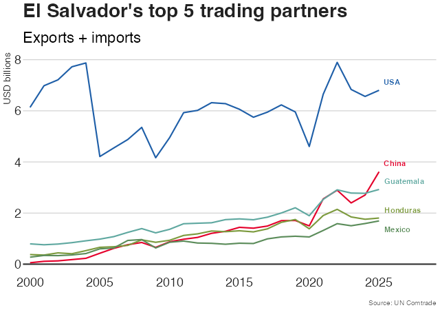

### Guatemala

The political climate in Guatemala is characterised by deep polarisation, the instrumentalisation of the judicial system for political purposes, and the penetration of criminal organisations and sophisticated corruption networks into state institutions (European Union Election Follow-up Mission 2025). The country saw a significant political change with the election of Bernardo Arévalo in 2023 and his inauguration in January 2024. His election was followed by months of political uncertainty, as opponents sought to challenge the result through legal and procedural means. The Attorney General’s Office and other judicial actors pursued cases against members of Arévalo’s *Semilla Movement*, the political party that brought him to power, whose legal status was definitively cancelled in March 2026. Arévalo’s victory was initially greeted with considerable optimism, but enthusiasm has since been tempered by frustration among some of his supporters, who had expected more rapid and far-reaching change (Freeman 2026b). Arévalo’s ability to implement his agenda is constrained by his lack of a majority in Congress and by the broader fragmentation of the political system. He has deliberately sought to pursue reform within the existing constitutional and legal framework rather than confront entrenched interests through extra-legal means. This approach reflects his commitment to democratic and constitutional procedures, but has also fuelled a debate among reformers over whether such caution is sufficient to dismantle deeply entrenched networks of corruption and political influence (Freeman 2026b).

Arévalo’s administration has nevertheless made progress in some areas of public service provision and institutional reform. The government has expanded recruitment in education and reported improvements in school infrastructure and healthcare provision. However, major legislative initiatives on corruption and judicial reform have been stalled or blocked in a fragmented Congress in which Arévalo lacks a majority.

Cooperation with the United States on counternarcotics and organised crime provides a channel for continued communication and interaction between the two administrations, but does not imply close political alignment. Arévalo’s opponents have courted President Trump to try to tip the scales against reformers (Freeman 2026b). In March 2026, it was revealed that US embassy staff, including the US ambassador to Guatemala, had called reluctant Guatemalan lawmakers to pressure them to approve a controversial Constitutional Court judge whose past associations with drug traffickers and gang members had raised concerns (AFP 2026; Freeman 2026b). The revelations prompted President Arévalo’s administration to seek explanations from the US State Department (Menchú 2026). Ultimately, with the appointment of the contested candidate, Roberto Molina Barreto, the Court is tied between reformers and their opponents, leaving Arévalo without a reliable majority on the Court.

Guatemala’s next general elections are scheduled for 2027. Arévalo is constitutionally barred from seeking a second term, and no unifying candidate has yet emerged from his political camp capable of continuing and consolidating his reforms, raising the risk that they could be reversed under a new government.

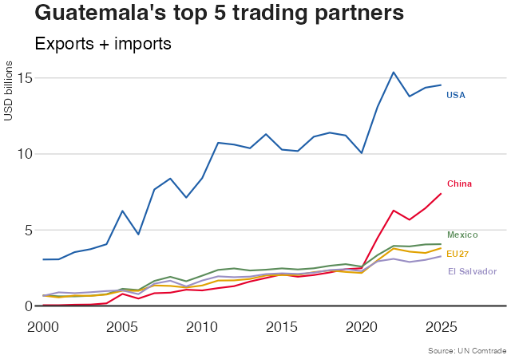

### Guyana

Guyana’s political development since 2000 has been shaped by a deeply polarised party system, ethnic divisions and, more recently, the extraordinary transformation brought about by the discovery of vast offshore oil reserves. By 2020, the Stabroek Block alone was estimated to contain more than eight billion barrels of recoverable resources, potentially giving Guyana a reserve base larger than those of Mexico and Colombia combined, an extraordinary source of wealth for a country with a population of less than one million people (Cahill 2020). For much of this period, politics was dominated by the People’s Progressive Party/Civic (PPP/C), traditionally associated with the Indo-Guyanese population, which accounts for around 40 per cent of the population, and the People’s National Congress and its successors, historically associated with Afro-Guyanese voters, who represent approximately 29 per cent. Both parties are formally broadly centre-left, but Guyanese politics has long been structured more strongly around ethnic and historical loyalties than ideological differences. Bharrat Jagdeo of the PPP/C, who had assumed the presidency in 1999, was re-elected in 2001 and again in 2006 (World Population Review 2026).

Donald Ramotar succeeded Jagdeo in 2011, but his presidency was marked by growing conflict between the government and an opposition-controlled National Assembly. After the 2015 election, the opposition coalition led by David Granger won power, ending more than two decades of PPP/C government. Granger’s administration was subsequently weakened by a successful no-confidence vote in December 2018, triggering a prolonged political and legal crisis. Although the Caribbean Court of Justice ruled that elections should be held within the constitutional timeframe, the vote was delayed until March 2020 (European Union Election Observation Mission 2020).

The March 2020 election took place as Guyana was beginning to reap the benefits of major offshore oil discoveries made by ExxonMobil in 2015. How the country’s newly discovered oil wealth would be managed and distributed became a central issue during the campaign. The agreement signed in 2016 with the US oil companies ExxonMobil and Hess Corporation, and China’s state-owned China National Offshore Oil Corporation (CNOOC), attracted considerable criticism for offering Guyana what many considered an inadequate share of future oil revenues. Hess was an independent US oil and gas company at the time; it was acquired by Chevron in July 2025. CNOOC, through its subsidiary CNOOC Petroleum Guyana Limited, holds a 25% stake in the Stabroek Block, alongside ExxonMobil (45%) and Hess’s successor, Chevron (30%). A 2020 Global Witness report estimated that Guyana could lose up to $55 billion in revenue as a result of the agreement’s terms. The controversy reflected broader concerns about whether the country had secured a fair deal and would receive an adequate share of the proceeds from its rapidly expanding oil industry (Business & Human Rights Resource Centre 2020; Chevron Corporation 2025; CNOOC Limited 2025).

Although Irfaan Ali and the PPP/C won the election, the transfer of power was delayed for five months amid attempts to manipulate the vote count in favour of Granger’s coalition. The EU Election Observation Mission concluded that voting and counting had generally been well managed, but that the integrity of the overall process had been seriously compromised by the non-transparent and non-credible tabulation of results in the decisive Region Four. A national recount and sustained international pressure eventually resulted in Ali’s inauguration in August 2020. The crisis exposed the fragility of Guyana’s democratic institutions at precisely the moment when the country’s oil wealth was beginning to transform its economic and geopolitical importance (European Union Election Observation Mission 2020).

Under Ali, Guyana has experienced one of the world’s fastest rates of economic growth. Oil production has rapidly expanded and the country has moved from being one of South America’s poorest states to one of its fastest-growing economies. However, the boom has also generated concerns about inequality, corruption and whether oil wealth is being distributed equally among the country’s ethnically divided population. These tensions have become increasingly visible as rapid economic growth has transformed Georgetown while many Guyanese continue to face high living costs, inadequate infrastructure and poor public services (Romero and Elliott 2026).

The oil boom has also fundamentally changed Guyana’s relationship with the United States. The United States is one of Guyana’s largest trading partners, second only to the EU27 when treated as a single bloc, while ExxonMobil has become the dominant actor in the country’s oil industry. Washington has simultaneously expanded security cooperation with Georgetown, particularly in response to the territorial dispute with Venezuela over the oil-rich Essequibo region. Under Nicolás Maduro, Venezuela intensified its claims to the territory, taking steps towards its annexation and raising concerns about the possibility of military action against Guyana. In March 2025, President Ali and US Secretary of State Marco Rubio agreed to deepen cooperation on security and transnational crime. During the visit, Rubio warned that a Venezuelan attack on Guyana or ExxonMobil’s operations would have serious consequences. Maduro was captured by US forces in January 2026 and removed from power. His former vice-president, Delcy Rodríguez, assumed the interim presidency with Washington’s backing, and her government has since operated under substantial US oversight. Although Venezuela’s territorial claim to Essequibo remains formally in place, the US intervention has fundamentally altered the balance of power in the dispute and curtailed Venezuela’s ability to pursue its territorial ambitions. Against this backdrop, Ali subsequently stated that the United States would receive preferential treatment in recognition of its support for Guyana’s security. The comments drew a sharp response from China, which highlighted its importance as a trading partner and its involvement in major infrastructure projects, including the new Demerara Harbour Bridge, six regional hospitals and road construction. Guyana’s relationship with the United States has therefore become increasingly intertwined with both the development of its oil industry and its security concerns, while making its relationship with China more politically sensitive (Associated Press 2025; Berg 2026; U.S. Department of State 2024).

Closer relations with Washington have not, however, resulted in a geopolitical break with China. Guyana has maintained diplomatic relations with Beijing since 1972 and continues to support the One China policy. China has become an increasingly important economic partner through trade, investment and infrastructure projects, while Chinese companies have expanded their presence in sectors including construction, healthcare and energy. The Ali government has therefore sought to maintain strong relations with both powers, even as competition between them for influence in Guyana has become increasingly visible (Associated Press 2025; International Monetary Fund 2025).

Guyana’s foreign policy is therefore increasingly shaped by its relations with three major external partners. The United States provides its most important security partnership and remains deeply connected to the country’s oil sector through ExxonMobil. China is an important trading partner, investor and infrastructure provider. The EU27, when treated as a bloc, is Guyana’s largest trading partner. For Guyana, the central challenge will be to convert its extraordinary new wealth into lasting development while preserving domestic political stability and navigating growing competition between the United States and China (Romero and Elliott 2026).

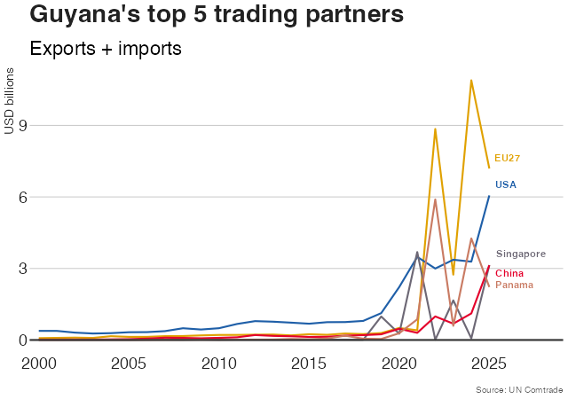

### Haiti

Haiti’s last presidential election was held in October 2015. The country is now preparing for elections scheduled for 13 December 2026, but severe logistical and security challenges have raised doubts about whether they can take place as planned, with many experts expecting a postponement (Paultre and Robles 2026). Haiti has been under pressure from the international community, including the United States, to restore an elected government. However, insecurity has displaced large numbers of voters and prevented many from returning to their communities to cast their ballots, while kidnappings and killings remain pervasive. This has created a fundamental dilemma: while some argue that elections cannot be held without first restoring security, others see an elected government as a prerequisite for restoring legitimate state authority and security.

Haiti last elected a president in 2016, when Jovenel Moïse came to power. He was assassinated in July 2021, after which gang violence, already a persistent feature of Haitian politics and society, escalated further, culminating in a major surge in violence in early 2024 (Paultre and Robles 2026). Armed groups still control large parts of Port-au-Prince and have expanded their presence beyond the capital. The Kenya-led Multinational Security Support Mission began deploying in June 2024, with the aim of supporting the Haitian national police and creating conditions for elections, but suffered from severe funding and personnel shortages and never reached its planned strength of 2,500 personnel. In September 2025, it was replaced by the UN-authorised Gang Suppression Force, with a planned strength of 5,500 personnel but only around 1,500 had been deployed by September 2026 (United Nations Support Office in Haiti 2026). With elections already six years overdue, pressure to hold them is considerable, but the continuing security crisis raises doubts about whether they can take place as planned and whether voters across the country will be able to participate.

### Honduras

Honduras was governed by the conservative *Partido Nacional* for twelve consecutive years, from 2010 to 2022, first under Porfirio Lobo and then under Juan Orlando Hernández (JOH), with the sole interruption being the presidency of Xiomara Castro (2022–2026), wife of Manuel Zelaya, who was ousted in a coup in 2009. The victory of Nasry “Tito” Asfura in the November 2025 elections therefore represented a return to power for the party that had dominated Honduran politics for much of the preceding decade. His victory was exceptionally narrow, with a margin of roughly 27,000 votes (European Union Election Observation Mission 2026a), and remains contested as the runner-up, Salvador Nasralla, refuses to recognise the result and alleges electoral fraud. One development that has intensified the allegations is the publication in August 2026 of audio recordings by a former member of the electoral tribunal, Marlon Ochoa, in which Argentine political consultant Fernando Cerimedo, who advised the *Partido Nacional* campaign, is heard stating that votes were introduced in favour of Asfura in certain ballot boxes and that votes unfavourable to the candidate were removed (Duarte Galleguillos 2026).

Asfura’s victory was also closely associated with Donald Trump, who openly intervened in the campaign days before the election, endorsing Asfura and warning that US support could be reconsidered if he lost (Wagner and Ernst 2025). Two days before the election, Trump also announced a full pardon for Juan Orlando Hernández (Correal et al. 2025), the former president convicted in 2024 by a US federal court of conspiring to import cocaine into the United States and sentenced to 45 years in prison. On paper, JOH had been a close US ally in the fight against drugs, as his governments cooperated extensively with Washington on counternarcotics and security. Yet US prosecutors subsequently alleged that he had used the Honduran state and his political power to facilitate the trafficking of more than 400 tonnes of cocaine to the United States in exchange for millions of dollars in bribes. His younger brother, Juan Antonio “Tony” Hernández, a former Honduran congressman, was arrested in 2018, convicted in the United States of cocaine trafficking, and sentenced to life imprisonment plus 30 years.

The pardon acquired a new dimension in 2026 following the publication of a series of leaked recordings known as “Hondurasgate”. The recordings, made between January and April 2026 and published in April, purport to document conversations involving Hernández, Asfura and Vice President María Antonieta Mejía. In the recordings, Hernández claims that individuals linked to Israel, including Prime Minister Benjamin Netanyahu, were involved in securing and financing his pardon (Hondurasgate 2026a). The recordings further allege that Hernández, with support from Republican allies of Trump and Argentine President Javier Milei, discussed establishing a conservative media operation capable of attacking the governments of Gustavo Petro in Colombia and Claudia Sheinbaum in Mexico, while planning his own return to the Honduran presidency in exchange for granting the United States a new military base and expanded control over Honduras’s special economic zones (Hondurasgate 2026b).

The case therefore illustrates a striking paradox. Hernández was convicted by the US justice system after prosecutors accused him of facilitating hundreds of tonnes of cocaine shipments, yet Trump subsequently pardoned him and backed the candidate of Hernández’s own party in a closely contested election. The pardon allowed Hernández to return to Honduras and resume his political influence in the country.

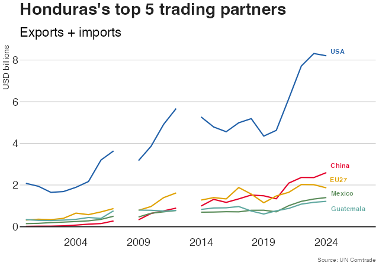

### Mexico

Mexico’s political trajectory since 2000 has been marked by the end of the Institutional Revolutionary Party’s (PRI) long dominance, which lasted continuously from 1929 until 2000, presiding over a one-party-dominant system characterised by patronage and an uneven political playing field. In 2000, Vicente Fox’s victory for the National Action Party (PAN), a generally conservative, centre-right party, ended this 71-year period (Tuckman 2000). His successor, fellow PAN politician Felipe Calderón, won the closely contested 2006 election and launched a militarised campaign against drug cartels, contributing to a prolonged escalation in violence. The PRI returned to the presidency in 2012 under Enrique Peña Nieto, whose government pursued market-oriented structural reforms (Tuckman 2012). However, the failure of established parties to address persistent security, corruption and poverty problems let to the rise Morena (*Movimiento Regeneración Nacional*, or National Regeneration Movement) and the landslide victory of leftwing populist Andrés Manuel López Obrador in 2018 (T. Phillips 2018).

Morena, established as a political movement by López Obrador, widely known as AMLO, represents a break with the established parties, combining a left-wing, redistributive agenda with economic nationalism and a populist political style. AMLO pledged to end what he described as the privileges of the political elite, making the fight against corruption and inequality central to his appeal. His so-called *Fourth Transformation* expanded social programmes, including pensions and scholarships, and oversaw substantial increases in the minimum wage. He also promoted a more interventionist economic model and defended the role of the state in strategic sectors, particularly energy (T. Phillips and Agren 2018). His personal popularity and direct communication style, especially through daily morning press conferences, became defining features of his presidency.

In 2024, Mexico became a notable exception to the broader anti-incumbency trend in Latin America, where voters have repeatedly removed governing parties from power, mostly left leaning governments. Barred by the Constitution from running again, López Obrador handed the presidency to a successor from his own party, Claudia Sheinbaum, who won another landslide victory with 59.5 per cent of the presidential vote, thereby becoming Mexico’s first female president and receiving more votes than any previous presidential candidate in the country’s recent history. Sheinbaum has largely continued AMLO’s political project and public style, retaining the emphasis on social programmes, higher wages, state-led development and direct communication with the public. Her background distinguishes her from her predecessor as she trained as a physicist, holds a doctorate in energy engineering and worked as a climate scientist. Her more measured and methodical manner contrasts with López Obrador’s folksier and more confrontational approach, but the political continuity between the two administrations remains clear (Arroyo 2024; Graham 2024). Sheinbaum’s approval ratings remain very high with 68% of the population considering her performance as positive in August 2026, which makes her one of the world leaders with the highest approval ratings (MND Staff 2026).

Relations with the United States remain essential but contentious. The US is Mexico’s principal trading partner, and the review of the United States–Mexico–Canada Agreement (USMCA) is particularly consequential for its export-oriented economy. Although Donald Trump built part of his political appeal on attacking Mexico, his second administration has increasingly relied on cooperation with President Claudia Sheinbaum. Encounters at the US border had fallen by 87 per cent compared with the final full month of the Biden administration (Nicas, Rodríguez Mega, and Kanno-Youngs 2026). Mexico has also secured comparatively favourable tariff treatment. Although Trump has threatened tariffs against the country, Mexico, which accounts for roughly one-sixth of all US trade, has effectively faced the lowest tariff rate of any major US trading partner (Nicas, Rodríguez Mega, and Kanno-Youngs 2026). Nevertheless, Washington continues to press Mexico to curb migration and drug trafficking while seeking to reduce its trade deficit. Sheinbaum has responded pragmatically, pursuing a trade agreement and exploring increased purchases of US goods, while insisting that cooperation must respect Mexican sovereignty. Tensions persist over US visa revocations targeting Mexican figures accused of links to organised crime and reports of US intelligence activity on Mexican soil. Plans for US airstrikes against cartel targets in Mexico have reportedly been shelved, at least temporarily, amid closer security cooperation. Mexico consequently faces the difficult task of securing favourable trade terms and maintaining security cooperation without appearing to accept US demands at the expense of national sovereignty (Nicas, Rodríguez Mega, and Kanno-Youngs 2026).

Mexico’s relationship with China has become more complicated as Washington seeks to limit Beijing’s economic influence in North America. China is a major source of Mexican imports, while the trade relationship is heavily imbalanced in China’s favour. In late 2025, Mexico approved higher tariffs, reaching up to 50 per cent on some products, on imports from countries with which it has no free-trade agreement, including China. The measures, covering a broad range of product categories and taking effect in 2026, were presented by the Mexican government as a means of protecting domestic industry, employment and national production (Alegría 2025; Reuters 2025a).

Morena appears well positioned to remain competitive in the near term, given Sheinbaum’s high approval ratings, the party’s organisational strength and the weakness of its divided opponents. Mexico’s Constitution prohibits presidential re-election and Sheinbaum will therefore have to leave office in 2030. Morena must identify a successor capable of maintaining its broad electoral coalition and attracting support in their own right, without relying on the personal popularity of either Sheinbaum or López Obrador. The opposition has yet to produce an equally dominant figure. The PAN remains the principal established conservative force, while the PRI, the former ruling party, is considerably weakened.

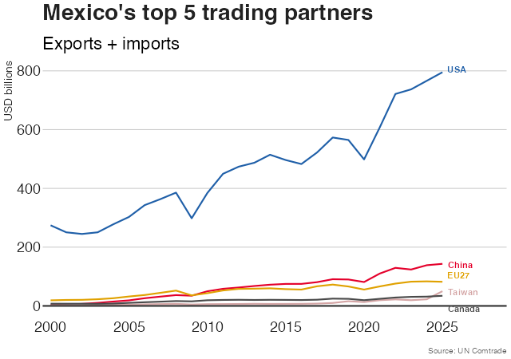

### Nicaragua

Nicaragua’s political trajectory since 2000 has been dominated by the return to power of Daniel Ortega and the progressive transformation of the Sandinista National Liberation Front (FSLN) from a revolutionary movement into the foundation of an increasingly authoritarian political system. Ortega was one of the leading figures of the Sandinista Revolution, which overthrew the US-backed Somoza dictatorship in 1979. He subsequently led the country as coordinator of the Junta of National Reconstruction and served his first offical term as president from 1985 to 1990. Between 1990 and 2007, Nicaragua was governed by three consecutive center-right administrations. Ortega’s return to power in 2007, despite just winning under 38% of the vote, followed a significant pragmatic turn, including an accommodation with conservative former president Arnoldo Alemán through a political pact that helped both leaders strengthen their control over the political system, not least by lowering the threshold for victory in presidential elections. Having initially presented himself as a more moderate candidate, Ortega returned to office promising social programmes and greater inclusion, while maintaining a pragmatic relationship with the private sector and benefiting from support from Hugo Chávez’s Venezuela (Campbell 2001; Carroll 2009).

Once back in power, Ortega progressively weakened institutional checks and balances, restricted political competition and secured the conditions for indefinite re-election. His government initially retained some electoral legitimacy, but the transformation became increasingly apparent as he concentrated control over the judiciary, electoral authorities and state institutions. The decisive rupture came in April 2018, when protests initially triggered by proposed social-security reforms broadened into demands for Ortega’s resignation. The government responded with a violent crackdown that left more than 300 people dead and thousands injured. Repression subsequently expanded to encompass opposition parties, independent media, universities, religious organisations and civil society. In the November 2021 presidential election, leading opposition candidates had been arrested or forced out of the country, and independent political competition was effectively eliminated. Ortega secured another term in an election widely rejected internationally. In September 2026, UN experts concluded that Nicaraguan state institutions had carried out enforced disappearances, torture and arbitrary detention as part of a systematic campaign against political opponents (Human Rights Watch 2026b).

Ortega’s wife, Rosario Murillo, has become central to this consolidation of power. Having served as his campaign communications chief in 2001 and subsequently as the government’s principal spokesperson, she became vice-president in 2017. A constitutional overhaul that entered into force in February 2025 formally established a co-presidency, making Murillo co-president alongside her husband and providing a constitutional framework for dynastic succession. The reform also concentrated power in the executive, subordinating other state institutions to the presidency and extending the presidential term from five to six years. Nicaraguan outlet *Confidencial* has reported that Murillo increasingly directs the government’s day-to-day operations, including political appointments, party organisation, communications and relations with foreign partners, while Ortega’s role has become more ceremonial. The couple’s children also occupy influential positions in government, investment promotion and state-aligned media, reinforcing the increasingly familial character of the system (Redacción Confidencial 2026).

The authoritarian consolidation has continued in 2026. Ortega publicly declared in July that Nicaragua would hold no further elections, to prevent the opposition from “seizing the government” again. In September, the National Assembly approved the first vote on a further constitutional amendment that would extend presidential and other elected terms from six to seven years and prohibit opposition parties from participating in elections. These developments point towards the further institutionalisation of a system in which electoral competition would no longer constitute a meaningful route to political change (Nicas and Wagner 2026; Selser and Cortes 2026).

Relations with the United States and Western governments have deteriorated in parallel with the domestic crackdown. Washington has imposed successive sanctions on Nicaraguan officials and regime-linked businesses, while European governments have also taken restrictive measures over human-rights violations. In April 2026, the US Treasury Department sanctioned two of the presidential couple’s sons, alongside officials and companies linked to the gold sector and the seizure of US-owned property. In October, the Ortega–Murillo government rejected the appointment of Natasha Franceschi as the next US ambassador. Washington subsequently recalled its chargé d’affaires, Elias Baumann, to the United States for consultations, deepening a diplomatic crisis that had already left the country without a US ambassador for several years (Reuters 2026b; U.S. Department of the Treasury 2026).

Nicaragua increasingly finds itself in international self isolation. In January 2026, Nicaragua expelled Spanish ambassador Sergio Farré Salvá and the embassy’s second-ranking diplomat without publicly explaining the decision. Spain responded by expelling Nicaragua’s ambassador in Madrid and another Nicaraguan diplomat in application of strict reciprocity. The incident followed several years of deteriorating relations, during which Managua has expelled or obstructed the work of foreign diplomats and international organisations, including representatives of the European Union and other Western countries. Nicaragua has also expelled numerous international organisations, ranging from the Organisation of American States and the Office of the UN High Commissioner for Human Rights to the Food and Agriculture Organisation and the International Committee of the Red Cross (González 2026; Pinell 2026).

Against this backdrop, Nicaragua has sought to strengthen relations with China and Russia. In December 2021, Managua restored diplomatic relations with Beijing, abandoning its longstanding diplomatic recognition of Taiwan in favour of the People’s Republic of China. The two countries subsequently elevated their relationship to a strategic partnership, and a bilateral free-trade agreement entered into force in January 2024 (Cash 2023; Ministry of Foreign Affairs of the People’s Republic of China 2021). Russia’s role is more explicitly strategic and security-oriented. Moscow has continued to provide political backing for Ortega and maintained long-standing military ties dating back to the first Sandinista government during the Cold War (Reuters 2024c).

Nicaragua’s geopolitical position must also be understood in the context of the weakening of the regional alignment that once challenged US influence. Ortega’s government has long been part of the Bolivarian Alliance for the Peoples of Our America (ALBA), alongside Cuba and Venezuela, and has presented itself as a defender of sovereignty against US interventionism. The removal of Nicolás Maduro by US forces in January 2026 and the subsequent engagement between Venezuela’s acting president, Delcy Rodríguez, and Washington have significantly weakened this political alignment. Cuba, meanwhile, faces acute economic and energy pressures. Although these governments were never a fully coherent bloc, Nicaragua and Cuba now stand out as among the region’s most consistently confrontational governments towards Washington. China and Russia provide Managua with diplomatic and security support, but the weakening of its regional allies leaves Nicaragua more isolated (Chamorro 2026).

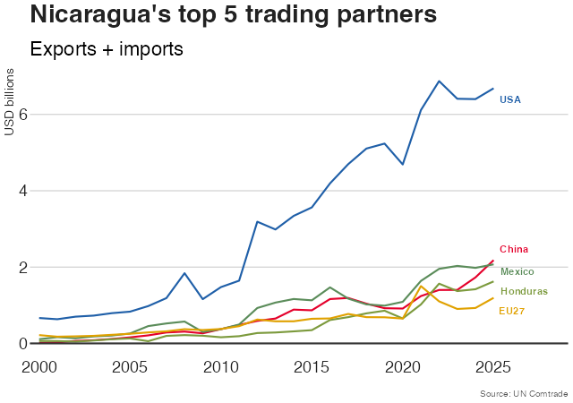

### Panama

José Raúl Mulino has been president of Panama since July 2024, when he took office after winning the May presidential election with 34.3% of the vote. Mulino had originally been running as the vice-presidential candidate of former president Ricardo Martinelli, who was constitutionally barred from standing after being convicted of money laundering. Martinelli nevertheless remained central to the campaign, and Mulino’s victory was largely built on his political support and the promise of returning to the economic policies associated with his presidency. Mulino has since pursued a broadly pro-business and security-oriented agenda, while facing the economic consequences of the closure of the Cobre Panamá copper mine and continuing concerns over migration through the Darién Gap.

Relations with the United States have strengthened considerably under Mulino, particularly on security, migration and the Panama Canal. The military dimension of this cooperation has come into focus as in October 2026 it was reported that the first elements of a 600-soldier US Army battalion had begun deploying to a jungle-training facility in Panama, ahead of planned exercises with forces in Colombia and Honduras (Schmitt, Jaffe, and Correal 2026). The US Embassy in Panama disputed the reported deployment, stating that 120 US soldiers were attending a two-week training course and would return to the United States on 25 October (Embajada de Estados Unidos en Panamá 2026). Panama has cooperated closely with Washington on controlling migration through the Darién and combating drug trafficking, while the Trump administration has placed increasing emphasis on reducing Chinese influence around the Canal. In 2025, Panama announced that it would withdraw from China’s Belt and Road Initiative, becoming the first Latin American country to do so. Mulino also agreed to increased US military cooperation and to accept migrants deported from the United States. These agreements generated domestic controversy as former president Martín Torrijos and former presidential candidate Ricardo Lombana joined other critics in arguing that the arrangements threatened Panamanian sovereignty. Both subsequently had their US visas revoked, although the State Department did not explain the individual decisions (Robles 2025). Mulino has nevertheless repeatedly rejected claims that China controls the Canal, stressing that the waterway remains under Panamanian sovereignty.

The most important manifestation of the US-China rivalry in Panama has been the controversy surrounding the ports at the two entrances to the Canal. Since 1997, Balboa on the Pacific side and Cristóbal on the Atlantic side had been operated by Panama Ports Company (PPC), a subsidiary of the Hong Kong-based conglomerate CK Hutchison Holdings. Although the ports are separate from the Canal itself, their strategic location made their operation a major concern for Washington. In 2025, Panama’s Controller General accused CK Hutchison of failing to properly renew its concession and of owing the state $300 million in fees. The dispute coincided with CK Hutchison’s proposed $19 billion sale of its global port business, including the two Panamanian terminals, to a consortium led by BlackRock. The proposed sale was welcomed by Washington but strongly criticised by Beijing, turning the ports into a focal point of the broader US-China rivalry (Eavis 2025).

In January 2026, Panama’s Supreme Court declared unconstitutional the legal framework underlying PPC’s concession. Following publication of the ruling in February, the Panamanian authorities took control of the two terminals, with Mulino insisting that this did not constitute an expropriation but the implementation of a binding judicial decision (La Prensa Panamá 2026). CK Hutchison and PPC rejected the termination and reserved their right to pursue legal action, while Beijing said it would take measures to protect the legitimate interests of Chinese companies (Lasso 2026). The dispute therefore acquired an increasingly geopolitical dimension, with Panama caught between US pressure to reduce Chinese strategic influence and the importance of maintaining its economic relationship with China.

The port dispute has not, however, resulted in a complete rupture with Beijing. China is an important trading partner and major user of the Canal, while Chinese companies have invested extensively in Panama since diplomatic relations were established in 2017. Mulino has sought to preserve these economic ties while defending Panama’s decision on the ports. In February, he argued that China itself depended heavily on Panama because Chinese goods pass through the Canal and the country’s logistics infrastructure (Vega Loo 2026). In April, tensions increased further when Panama reported that dozens of Panama-flagged vessels had been detained in China. Mulino sought to de-escalate the dispute while investigating the detentions (Berríos Riaño 2026). The episode illustrates that Panama’s closer strategic alignment with Washington has not eliminated its substantial economic interdependence with China.

Panama under Mulino therefore represents a clear case of closer strategic alignment with the United States, particularly on security, migration and strategically sensitive infrastructure, accompanied by a significant reduction in its engagement with China. At the same time, Mulino has continued to emphasise Panamanian sovereignty and sought to avoid a broader rupture with Beijing. The controversy over the CK Hutchison ports illustrates how US-China competition is increasingly shaping political and economic decisions in Latin America, particularly where Chinese commercial interests intersect with infrastructure of strategic importance to Washington.

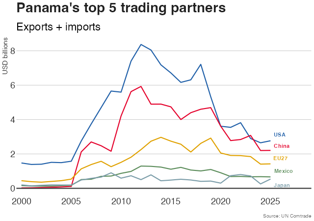

### Paraguay

Paraguay’s political trajectory since 2000 has been characterised by continuity rather than the alternation between left and right seen elsewhere in Latin America. The conservative Colorado Party governed uninterruptedly from 1947, including throughout Alfredo Stroessner’s dictatorship, until 2008 when Fernando Lugo came to power as the first former Catholic bishop to assume the presidency of a country in the region (Nickson 2008). Lugo was removed through a contentious impeachment process in 2012 and his Vice-President Federico Franco took over for the remaining year of the mandate. Since then, the Colorado Party has been in power again uninterruptedly.

In the 2023 general election, the Colorado Party’s candidate Santiago Peña, a former finance minister and International Monetary Fund economist, won approximately 43 per cent of the vote, defeating centre-left opposition candidate Efraín Alegre. The elections took place in a highly polarised environment marked by deep distrust in state institutions (L. Elliott and Desantis 2023; European Union Election Observation Mission 2023).

Peña’s presidency has been closely associated with former president Horacio Cartes, who remains one of the country’s most influential political figures. Cartes had sought to amend the constitution in 2017 to allow himself an additional term, but was forced to abandon his plans following widespread street protests, as the constitution has prohibited presidential re-election since 1992 following the fall of Stroessner’s military government, which lasted from 1954 to 1989 (BBC News Mundo 2017). He subsequently selected Peña as his preferred successor and backed his successful presidential campaign. Although Peña presents himself as a technocratic, pro-business leader focused on economic growth and foreign investment, critics have questioned his autonomy from Cartes. In January 2023, the US Treasury Department sanctioned Cartes and former Vice-President Hugo Adalberto Velázquez Moreno “for their involvement in the rampant corruption that undermines democratic institutions in Paraguay” (U.S. Department of the Treasury 2023). The Trump administration lifted the sanctions in October 2025, and Peña welcomed the decision as an improvement in bilateral relations. Opposition figures attributed the reversal to a series of pro-US foreign policy decisions, including an agreement to receive asylum seekers from the United States and Paraguay’s participation in Trump’s Shield of the Americas initiative, which Peña signed on 7 March 2026 at the inaugural summit held in Doral, Florida. A US State Department spokesperson stated that the sanctions were “no longer required to incentivise changes in behaviour, and therefore not in the foreign policy and national security interests of the United States” (Blair 2025; Desantis and Elliott 2025; Office of Foreign Assets Control 2025).

Concerns about institutional accountability have persisted under Peña. In February 2024, allies of Cartes in the Senate helped expel opposition senator Kattya González over alleged administrative misconduct, a decision that rights groups criticised as a violation of due process. Later that year, legislation imposing extensive reporting requirements on non-governmental organisations entered into force, raising concerns among opposition parties, UN experts, and civil society organisations that the law would effectively allow the government to persecute groups it considered hostile (Freedom House 2025).

The October 2026 municipal elections provided an early indication of the challenges facing the governing party ahead of the 2028 general election. The Colorado Party retained its nationwide dominance and increased the number of municipalities under its control compared with 2021, but suffered significant defeats in Asunción, the capital, and Ciudad del Este, the country’s second-largest city. In Asunción, opposition candidate Soledad Núñez won 47.78 per cent of the vote against 45.98 per cent for the Colorado candidate. Núñez had been the running mate of Efraín Alegre of the Liberal Party in his unsuccessful 2023 presidential bid. These results do not amount to a national realignment, but they expose vulnerabilities in the governing party’s electoral machinery and offer the opposition an opportunity to build a more credible challenge ahead of 2028 (Agencia EFE 2026; Desantis 2026).

One of the most consequential aspects of Paraguay’s foreign policy is its continued diplomatic recognition of Taiwan. Paraguay is the only remaining country in South America and one of just twelve worldwide to maintain formal diplomatic relations with Taiwan. Under Peña, the government has repeatedly reaffirmed this commitment, including during his visit to Taipei in May 2026. The relationship encompasses cooperation in education, technology, and security, as well as access for Paraguayan agricultural exports to the Taiwanese market. However, the Taiwanese market cannot compete with the Chinese one, and there is growing pressure from Paraguayan farmers to abandon the relationship with Taipei and establish formal ties with Beijing (L. Elliott and Desantis 2023). Despite the absence of formal diplomatic relations, Paraguay maintains substantial trade with China, valued at approximately $5 billion in 2024. Paraguayan officials have indicated openness to commercial and other relations with Beijing, but have stated they will not accept the condition of severing ties with Taiwan (Johnson and Wu 2024).

The dispute intensified in October 2026 when China imposed sanctions on Paraguay’s Minister of Information and Communication Technologies, Gustavo Villate, and Belize’s foreign minister over their countries’ continued ties with Taiwan. Beijing accused the officials of supporting Taiwan’s independence and spreading disinformation about Chinese cyberattacks. The measures included asset freezes in China, entry restrictions, and a ban on Chinese organisations and individuals cooperating with the sanctioned officials; their practical impact is largely symbolic (Lee and Blanchard 2026). Paraguay rejected the sanctions and reiterated its support for Taiwan, while the US State Department condemned them as coercive measures against countries exercising their sovereign foreign-policy choices (ABC Color 2026; Reuters 2026d).

In November 2026, the collapse of Ueno Bank triggered Paraguay’s most serious political and financial crisis in years and brought down President Santiago Peña. The central bank intervened in the bank after identifying serious solvency problems, freezing the accounts of nearly three million customers, about 60% of the country’s adult population. Prosecutors subsequently accused Peña of using his political influence to direct hundreds of millions of dollars in public funds towards Ueno, while its executives engaged in risky lending to companies linked to insiders. After attempting to resign, apparently to retain the legal protections available to former presidents, his resignation was rejected and Congress impeached him, removing him from office. He was subsequently placed under house arrest before being transferred to a military base amid fears that he could be lynched by citizens outside his home. The crisis also exposed broader economic risks, as hundreds of millions of dollars in public and pension funds had been deposited with Ueno, raising concerns about wider consequences for Paraguay’s financial system. The episode represents the most serious challenge to Colorado Party rule since its return to power in 2013 and could have significant implications for the political landscape ahead of the 2028 general election. (Ellick and Blair 2026; Rogero 2026c).

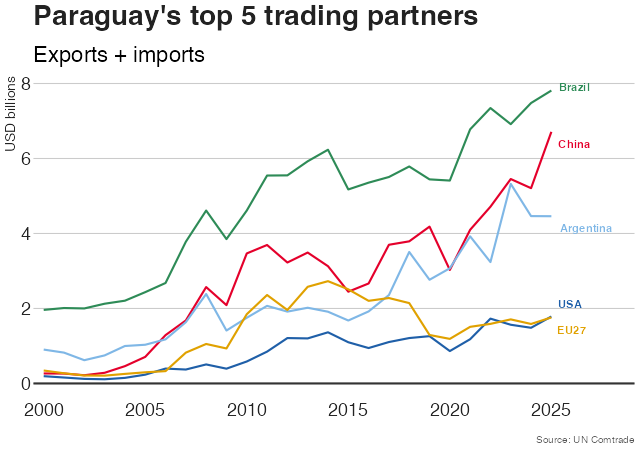

### Peru

Peru’s political trajectory since 2000 has been marked by the collapse of Alberto Fujimori’s authoritarian government, an initially promising democratic transition and, more recently, chronic presidential instability. Fujimori fled the country in November 2000 amid a corruption scandal that exposed the systematic bribery of politicians and other public figures by his intelligence chief, Vladimiro Montesinos. His departure ushered in a transitional administration under Valentín Paniagua, followed by the election of Alejandro Toledo in 2001. Toledo, Alan García (2006–2011) and Ollanta Humala (2011–2016) all completed their presidential terms, but successive corruption scandals, including the far-reaching Odebrecht affair, undermined public confidence in the political establishment. Fujimori’s legacy also remained influential as his daughter Keiko emerged as the leading figure of *fujimorismo*, the political movement associated with her father’s rule, and became one of the most prominent conservative politicians in the country (Collyns and Jones 2024; Gómez Vega 2025).

The breakdown in presidential stability accelerated after Pedro Pablo Kuczynski took office in 2016. He resigned in March 2018 amid an escalating impeachment crisis linked to allegations concerning the Odebrecht corruption scandal. His successor, Martín Vizcarra, was removed by Congress in November 2020, triggering mass protests that forced interim president Manuel Merino to resign after just five days. Francisco Sagasti then served as a caretaker president until the 2021 election, won by left-wing outsider Pedro Castillo. Castillo’s confrontation with Congress culminated in December 2022, when he attempted to dissolve the legislature and govern by decree; Congress removed him and he was arrested on rebellion charges and sentenced to 11 years in prison in 2025. His vice-president, Dina Boluarte, succeeded him but was eventually removed in October 2025 amid mounting insecurity, protests and political scandals. Her successors, José Jerí and interim president José María Balcázar, further illustrated the fragility of the executive as Jerí was removed after four months, while Balcázar held office until the inauguration of the newly elected president in July 2026. Peru had thus experienced nine presidencies in roughly a decade, reflecting the combination of fragmented parties, minority governments, corruption scandals and recurrent conflict between Congress and the executive (Council on Foreign Relations 2026c; Gómez Vega 2025).

Against this backdrop, the June 2026 presidential run-off brought *fujimorismo* back to power a quarter of a century after the collapse of Alberto Fujimori’s government. After three unsuccessful presidential campaigns, Keiko Fujimori defeated left-wing candidate Roberto Sánchez by just 49,641 votes, becoming the first woman elected directly to Peru’s presidency. Her victory was nevertheless unusual as she received fewer votes than Sánchez within Peru itself, with the overseas vote tipping the national result in her favour (European Union Election Observation Mission 2026b; Glatsky 2026). The return of *fujimorismo* also creates an evident political irony. Over the preceding decade, *Fuerza Popular*, the party led by incumbent president Fujimori, alone or in alliance with other parties, participated in the removals of four presidents: Martín Vizcarra, Pedro Castillo, Dina Boluarte and José Jerí. The movement that had repeatedly used its influence in Congress to undermine other presidents must now govern without a legislative majority of its own (Zambrano 2026).

The limits of that power have already become apparent. Fuerza Popular holds only 41 of the 130 seats in the lower chamber, forcing the government to negotiate with other parties to pass legislation. In October 2026, Congress substantially curtailed Fujimori’s request for temporary powers to legislate by decree as of the 66 measures proposed by the government, only 20 were approved, and the authorisation period was shortened from 120 to 90 days. Even some parties previously regarded as allies opposed the government’s proposals, including its request to give the armed forces a greater role in prison security (Zambrano 2026). Her popularity has also fallen sharply. According to recent polling, her approval rating dropped by 14.5 percentage points to 28.3 per cent in early October 2026, while disapproval rose to 53.6 per cent (Bloomberg News 2026). These early difficulties suggest that winning the presidency has not resolved the structural problems that have repeatedly destabilised Peruvian governments. As under her predecessors, Fujimori must contend with a fragmented legislature, widespread distrust of political institutions and public expectations that may prove difficult to meet.

The change of government has also brought a shift in foreign policy orientation. The clearest signal is the appointment of Carlos Espá as Foreign Minister. Having served as communications director in the press and culture department of the US Embassy in Lima from 2008 to 2023, Espá confirmed upon taking office that Peru would join Trump’s Shield of the Americas coalition as part of Fujimori’s security agenda, describing the United States as a “strategic partner.” Relations with China, however, are unlikely to undergo any dramatic change, given Beijing’s centrality to the Peruvian economy. China has become Peru’s largest trading partner and a major investor in mining, energy, and infrastructure. When the 2008 financial crisis depressed US and European demand for minerals, China’s construction boom continued to absorb Peruvian copper and iron, and Beijing eventually surpassed Washington as Lima’s principal trading partner, today purchasing roughly a third of the country’s exports. Beyond trade, Chinese state-owned enterprises have steadily expanded into sectors from which Western businesses have retreated, including Lima’s electricity distribution system, as well as transportation, banking, and telecommunications (Glatsky 2026).

China also financed the $1.3 billion Chancay mega-port north of Lima, which has become a particular concern for Washington. The port was a key issue during Secretary of State Marco Rubio’s visit to Peru in August 2026, as part of the Trump administration’s broader efforts to roll back Chinese influence in the Western Hemisphere (Glatsky 2026). In September 2026, the US State Department announced visa revocations targeting several current and former officials from Bolivia, Colombia, Ecuador and Peru (United States Department of State 2026). The only Peruvian national targeted was judge Juan Carlos Nuñez Matos, who had ruled in a case concerning the Chancay port that it constituted a private investment rather than a state concession. The ruling was opposed by the United States because it limited the regulatory oversight that could be exercised over the port (Center for Economic and Policy Research 2026). The State Department did not provide evidence or further details explaining the reasons for the visa revocation, but its timing and the judge’s involvement in the Chancay case raise the possibility that the two were connected.

The contrast in the nature of US and Chinese engagement with Peru is striking. While China has channelled investment into ports, mines, and electricity infrastructure, US engagement has focused predominantly on security cooperation funded by Peru itself, including a $1.5 billion modernisation of the country’s naval base and the purchase of 24 F-16 fighter jets at a cost of $3.5 billion (Glatsky 2026).

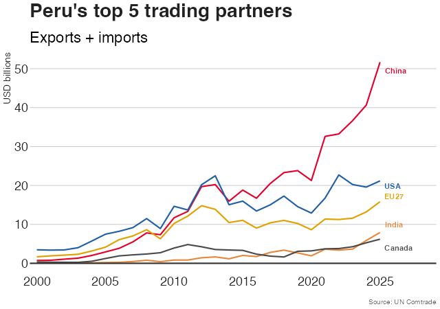

### Suriname

Suriname, with a population of approximately 660.000, is South America’s least populous sovereign country. Formerly known as Dutch Guiana, it gained independence from the Netherlands in 1975. Its political development since 2000 has been shaped by ethnic diversity, the legacy of repeated military interventions and dependence on natural resources, particularly gold and oil, which together account for nearly 90 per cent of its exports. The country returned to electoral democracy in 1991, after a decade marked by military rule under Desi Bouterse, who ruled as a dictator from 1980 to 1987. Ronald Venetiaan, who had first served as president from 1991 to 1996, returned to office after the New Front coalition’s victory in the 2000 elections. His governments maintained relative political stability until 2010, when former military ruler Bouterse returned to power through democratic elections, leading the multi-ethnic, left-wing populist National Democratic Party (NDP). He was re-elected in 2015 and remained president until 2020, despite his controversial political legacy. In 2019, he was sentenced to 20 years in prison for the 1982 killings of 15 political opponents. The conviction was upheld by Suriname’s Court of Justice in December 2023, but Bouterse went into hiding and died in December 2024 (Congressional Research Service 2025).

The period between 2010 and 2015 coincided with a commodity boom that temporarily strengthened Suriname’s economy and expanded its trade with major external partners, particularly the United States and the European Union. Rising international prices for gold, oil and, to a lesser extent, alumina increased export revenues and foreign-exchange earnings, while demand for machinery, equipment and industrial inputs fuelled imports. This growth reflected high global commodity prices rather than a broader diversification of the economy, however, leaving Suriname highly vulnerable when prices subsequently declined and the Suralco alumina refinery closed in late 2015, followed by the permanent closure of bauxite mines in 2016. The currency depreciated sharply, inflation rose and public debt increased substantially (International Monetary Fund 2016; World Trade Organization 2019).

The end of the commodity boom contributed to a severe economic and fiscal crisis that increasingly undermined Bouterse’s government. The 2020 elections brought Chan Santokhi and his Progressive Reform Party (VHP), which draws strong support from the Indo-Surinamese community, to power, ending a decade of NDP rule. Santokhi’s government negotiated a debt-restructuring programme and a $688 million IMF arrangement in 2021, while implementing austerity measures that included cuts to subsidies and increases in taxes and utility prices. Although these policies helped restore macroeconomic stability and reduce inflation, austerity and rising living costs generated significant protests and damaged the government’s popularity (International Monetary Fund 2021).

The May 2025 elections returned the NDP as the largest party, with 18 of the National Assembly’s 51 seats, narrowly ahead of the VHP. The NDP formed a six-party coalition with 34 seats, and its leader, Jennifer Geerlings-Simons, was elected president in July, becoming the country’s first woman to hold the office. Following the discovery of significant offshore oil reserves, her administration faces the challenge of translating the expected oil revenues into broad-based development while addressing persistent concerns over corruption, public finances and the distribution of resource revenues. Production is not expected to begin before 2028, meaning Geerlings-Simons cannot count on an immediate financial windfall. The development of the offshore GranMorgu field is led by French multinational TotalEnergies, alongside US-based APA Corporation and state-owned Staatsolie. The project reached a final investment decision in October 2024, with investment initially estimated at $10.5 billion. The NDP’s return to power represented less a simple ideological reversal than widespread frustration with the economic and political status quo (Rogero 2025).

Suriname’s foreign policy is increasingly shaped by the prospect of substantial oil revenues and competition for economic influence. The United States has maintained close relations with Paramaribo, combining an interest in expanding US investment, particularly in the emerging offshore energy sector, with security and law-enforcement cooperation. Bilateral cooperation has included military training and capacity-building against drug trafficking and financial crime, reinforced by a 2024 agreement between the DEA and Suriname’s Attorney General’s Office and discussions in 2025 on reopening a DEA office in the country (Congressional Research Service 2025; USAFacts 2026). The European Union remains an important economic partner, particularly through Suriname’s historical ties with the Netherlands, while China has expanded its presence through trade and investment, especially in infrastructure and natural resources (World Bank 2023).

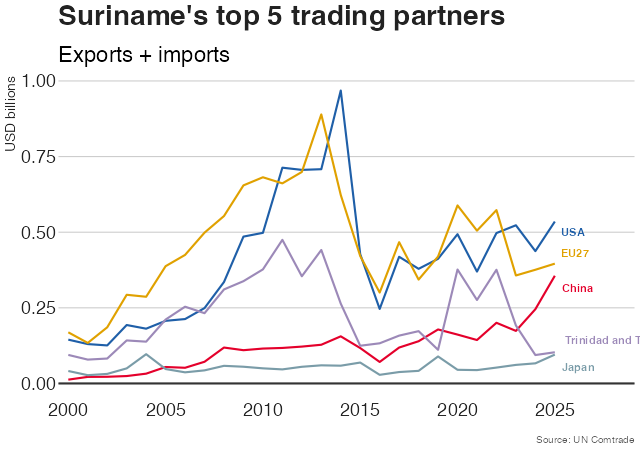

### Uruguay

Uruguay’s political trajectory since 2000 stands out in Latin America for the stability of its democratic institutions and the peaceful alternation of power between the left and the right. In the early 2000s, a severe financial crisis, compounded by Argentina’s economic collapse, undermined confidence in the traditional Colorado and National parties. The centre-left Broad Front (*Frente Amplio*) capitalised on this discontent to win the 2004 presidential election, bringing Tabaré Vázquez to power in 2005 and ending more than a century of political dominance by the traditional parties. Subsequent Broad Front governments under José Mujica (2010–2015) and Vázquez again (2015–2020) expanded social protection and introduced progressive reforms, including the legalisation of abortion, same-sex marriage and the state-regulated production and sale of cannabis (Baldock 2004; Cariboni 2014; Rivas Molina 2024).

The Broad Front lost the presidency in 2019 to Luis Lacalle Pou’s centre-right coalition, which governed from 2020 to 2025. In November 2024, however, Broad Front candidate Yamandú Orsi defeated Álvaro Delgado, the candidate of the outgoing coalition, and took office on 1 March 2025. True to Uruguay’s tradition of peaceful alternation, Lacalle Pou promptly recognised Orsi’s victory, and both camps pledged to cooperate during the transition. The campaign was comparatively moderate by regional standards, with established parties retaining their identities and political outsiders making little headway. Yet the result was not simply a return to the left after a temporary right-wing interlude. The Broad Front rebuilt its support through extensive local campaigning and by capitalising on dissatisfaction with the government’s record on crime and social problems, as well as scandals involving senior officials (El País 2024; Reuters 2024d).

Uruguay’s relative stability should not obscure persistent social divisions. Poverty and inequality remain unevenly distributed, with children disproportionately affected, while violent crime and concerns about education and the cost of living have become more prominent in public debate. These concerns helped shape the 2024 election despite the country’s comparatively robust social protection system and macroeconomic track record. Orsi has presented his programme as a “modern left”: continuing the Broad Front’s commitment to redistribution, while avoiding a sharp policy rupture and maintaining economic stability. His government must now demonstrate that Uruguay’s institutional stability can translate into tangible improvements for the social groups that have benefited least from previous progress (Reuters 2024d; Rivas Molina 2024).

Relations with the United States illustrate the pragmatic and sometimes uncomfortable character of Uruguay’s foreign policy. Orsi’s centre-left government has maintained dialogue with Washington, but it has not been immune to pressure from the Trump administration. In July 2026, it was reported that the US was seeking to use Uruguay as a destination for Cuban nationals deported from the United States, describing negotiations as close to an agreement. Uruguay had its own reasons to engage in negotiations. As a country with a historically open immigration policy and a small, ageing population in need of immigrant workers, it stood to benefit from the arrangement while simultaneously improving relations with the Trump administration (Wong and Bubola 2026). Uruguay was not among the countries invited to join Trump’s *Shield of the Americas*, launched in March 2026. President Orsi described the omission as surprising and said Uruguay was willing to cooperate on combating drug trafficking and organised crime. He proposed addressing these issues through the Community of Latin American and Caribbean States (CELAC), bringing all countries into the coordination effort rather than relying on a selective coalition (El País Uruguay 2026; Telenoche 2026).

China was Uruguay’s largest destination for goods exports in 2025, accounting for approximately 26 per cent of the total, with agricultural commodities central to the relationship. Orsi’s state visit to China in February 2026 brought a 150-person delegation of ministers, officials, business representatives, trade unionists and academics, underscoring that the relationship extends beyond presidential diplomacy. During the visit, Orsi also announced that Uruguay intended to seek accession to the Regional Comprehensive Economic Partnership (RCEP), a trade agreement among 15 Asia-Pacific economies that together account for approximately 30 per cent of global GDP (Association of Southeast Asian Nations 2020). The government presented the initiative as part of a wider effort to open markets and diversify trade, including improving access for products such as poultry and dairy. It should not be read as evidence of a straightforward geopolitical shift towards Beijing. Uruguay has an established interest in the Chinese market, and the pursuit of wider Asian trade links has also featured under previous governments. Nevertheless, the RCEP initiative raises practical questions, including how Uruguay’s ambition for greater trade autonomy would fit with Mercosur’s common commercial policy (Chu 2026; la diaria 2026; Uruguay XXI 2026).

Relations with the European Union provide another route for diversification. The EU–Mercosur agreement, signed in January 2026 after more than two decades of negotiations, began provisional application of its trade provisions on 1 May. Orsi and his foreign minister have presented it as an opportunity to expand trade and investment and strengthen ties with a major partner beyond the United States and China. However, the agreement is not without complications. As of June 2026, Mercosur members had still not agreed how to distribute some of the export quotas negotiated with the EU, exposing tensions over how the benefits of integration should be shared. For Uruguay, the deal offers valuable market access, but its benefits will depend on how the country captures a fair share of the quotas and whether increased trade volumes translate into broader industrial and productive development (Centenera 2026; Galarraga Gortázar and Colmán 2026; Rivas Molina 2026).

Mercosur remains both an instrument of influence and a constraint on Uruguay’s ambitions. As a small economy, Uruguay benefits from negotiating with larger partners as part of a regional bloc, yet successive governments have sought more flexibility to pursue trade opportunities independently. Under Orsi, the government has continued to advocate a more open and outward-looking Mercosur and has shown interest in exploring additional agreements with Asian partners. These aims place Uruguay between competing approaches within the bloc as Brazil stresses regional cohesion, while Argentina under Javier Milei has pushed more forcefully for freedom to negotiate bilateral deals. Orsi’s position has been closer to the argument for greater flexibility, but without abandoning Mercosur. This reflects a recurring dilemma for Uruguay where integration increases its collective leverage, yet restrictive common rules can limit its ability to respond quickly to opportunities in global markets (Galarraga Gortázar and Colmán 2026; Rivas Molina 2026).

In a regional environment increasingly shaped by right-wing governments and sharper geopolitical competition, Uruguay remains one of the relatively few centre-left administrations. Its foreign policy, however, is not organised around an anti-US bloc or an exclusive alignment with China. Instead, the government seeks to maintain workable relations with Washington, deepen commercial links with Beijing, strengthen the partnership with Europe and use Mercosur to widen its room for manoeuvre. The central tension is whether Uruguay can sustain this multi-directional approach when its partners increasingly seek political alignment as well as economic cooperation.

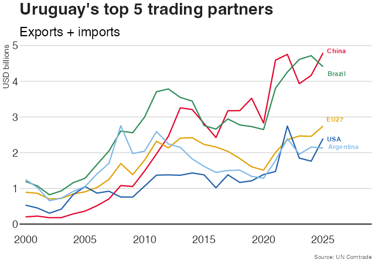

### Venezuela

Venezuela’s current crisis has its roots in Hugo Chávez’s rise to power in 1998 and his presidency from 1999. Elected on a promise to replace the discredited political establishment, Chávez used oil revenues to finance social programmes that reduced poverty and secured considerable popular support. However, his governments also progressively concentrated power in the executive. In 2004, the governing majority expanded the Supreme Court from 20 to 32 justices, enabling it to appoint government allies and weakening judicial independence. Pressure on critical media further eroded institutional checks and balances, although Chávez continued to win elections and retain significant popular support (Human Rights Watch 2013).

After Chávez’s death in 2013, his successor, Nicolás Maduro, narrowly won the presidential election. The subsequent collapse in oil prices exposed Venezuela’s dependence on petroleum exports, while economic mismanagement and corruption contributed to a deep recession, hyperinflation, shortages and mass emigration. The opposition’s victory in the 2015 legislative elections gave it control of the National Assembly, but the government-aligned Supreme Court progressively stripped the legislature of its powers, first blocking several opposition lawmakers from taking their seats and subsequently overturning legislation passed by the Assembly. In 2017, Maduro established a controversial Constituent Assembly without holding a referendum on its creation. The body subsequently assumed legislative powers and declared itself superior to other state institutions, further sidelining the opposition-controlled parliament. His re-election in 2018, boycotted by much of the opposition and widely condemned as illegitimate, deepened the political crisis (Council on Foreign Relations 2026b; Reuters 2024b).

In January 2019, Juan Guaidó, then president of the National Assembly, invoked constitutional succession provisions to declare himself interim president. The United States, Canada and many European governments recognised him, hoping to force Maduro from power and bring about new elections. However, Guaidó never gained control of the armed forces or the key institutions of the state, and the attempt to secure a political transition ultimately failed. The Venezuelan opposition dissolved his interim government in 2022, while Maduro remained in power despite international pressure and extensive US sanctions (Jones and Wintour 2019; Reuters 2024b).

Venezuela’s relations with Washington deteriorated as disputes over democratic governance, human rights and US sanctions intensified. Meanwhile, Chávez and Maduro strengthened ties with China and Russia as a counterweight to American influence. China extended tens of billions of dollars in credit and oil-for-loans arrangements from 2007 onwards, becoming Venezuela’s largest creditor and a major partner in its oil sector. Russia provided military cooperation and diplomatic support, helping Caracas withstand international isolation (Buitrago 2024; Council on Foreign Relations 2026b).

The opposition’s efforts to secure a democratic transition continued in the following years. In 2023, Maduro’s government agreed to electoral guarantees under the Barbados agreement in exchange for limited US sanctions relief. María Corina Machado won the opposition primary by an overwhelming margin, but the authorities barred her from running. Edmundo González Urrutia, a former diplomat, who initially registered as a placeholder, consequently became the opposition coalition’s unity candidate. After the July 2024 presidential election, the electoral authority declared Maduro the winner but failed to publish detailed polling-station results. The opposition collected and published tally sheets from more than 80% of polling stations, which indicated a decisive victory for González. The Carter Center was unable to corroborate the official result and concluded that the election could not be considered democratic. Washington subsequently restored broad oil sanctions, citing the government’s failure to meet its electoral commitments. Maduro nevertheless retained power, and the political deadlock persisted into late 2025, amid renewed US pressure (Council on Foreign Relations 2026b; Llaneras 2024; Reuters 2024a, 2024b).

The US military operation *Absolute Resolve*, launched on 3 January 2026, represents a watershed moment for Venezuela and the wider region. It marks the first time in recent history that the United States has captured a sitting president and transferred him to US soil to face trial, with Nicolás Maduro now detained in Manhattan awaiting proceedings. By establishing provisional authorities drawn from within the Chavista regime but approved by Washington, the United States transformed a country that had been a strategic adversary into something resembling a client state (R. F. Elliott, Romero, and Wong 2026).

The provisionality of these authorities, however, remains an open and deeply consequential question. Although no election date has been set, Washington has outlined a roadmap towards presidential elections. Under the plan, a new Supreme Tribunal of Justice is to be appointed by mid-December 2026, followed by reform and replacement of the National Electoral Council. Delcy Rodríguez would then have to declare a permanent vacancy in the presidency, triggering a six-month period for elections under the Venezuelan constitution (U.S. Department of State 2026).

On 31 August 2026, the White House announced that it had secured majority US control over more than 65 billion barrels of Venezuela’s proven oil reserves (The White House 2026). Venezuela is believed to possess the world’s largest oil reserves. What is particularly striking is that the country appears to have ceded control over its principal natural resource through a profoundly asymmetric arrangement to a private company run by an oligarch who made his fortune under Chavismo and is now firmly subordinated to US power. The company is partly owned by the US government, which exercises near-total control over its board of directors, while its contracts are governed by US law and subject to US courts. Indeed, since the era of decolonisation, no oil-producing country has surrendered its principal resources under comparable conditions (Le Grand Continent 2026a).

At the centre of the agreement is Lorenzo Betancourt, whose company, North American Blue Energy Partners (NABEP), has reportedly been granted 100-year concessions to operate 17 oil fields containing an estimated 65 billion barrels of reserves, roughly equivalent to the total proven reserves of the United States. Betancourt does not own the fields outright, but the concessions grant him exclusive exploitation rights. The arrangement is particularly striking in light of his legal history. Legal proceedings were initiated against him in Spain and Switzerland on money-laundering charges, and both countries requested his extradition from the United Kingdom, where he lives on a 14-bedroom country estate. British authorities arrested him less than a year ago and barred him from travelling abroad. Under the agreement between NABEP and the United States, the Pentagon holds a significant equity stake in the company. The arrangement is difficult to compare with any recent precedent in American history and places Betancourt at the centre of Venezuela’s transformation from a sovereign state into what critics describe as a vassal of the United States (Romero et al. 2026).

The White House acknowledged in its fact sheet that most of the oil fields to be operated by NABEP were previously controlled or operated by Russian and Chinese firms (The White House 2026). A document reviewed by *The New York Times* showed that China Concord Petroleum was participating in at least two of the 17 areas as recently as 2024. The company had been placed under US sanctions in 2019 for its alleged involvement in transporting Iranian oil. China’s foreign ministry responded that “China’s legitimate rights and interests in Venezuela must be guaranteed” (R. F. Elliott, Turkewitz, and Abraham 2026). Both China and Russia, which once exercised considerable influence in Venezuela, now appear to have limited leverage to alter the country’s new trajectory.

The interim leader, Delcy Rodríguez, has emphasised the substantial financial resources that the Venezuelan state stands to receive from the agreement. A figure of $200 billion has been cited, to be transferred over 25 years. Although this sum appears substantial, $200 billion spread over 25 years amounts to approximately $8 billion per year. Assuming production of between 2 and 2.5 million barrels per day, this would represent a state take of roughly $10 per barrel. That figure falls well below the level suggested by international benchmarks, under which a host state typically receives between 50 and 90 per cent of profits. Moreover, much of the promised $200 billion would reportedly be paid in the distant future, when production reaches its peak (Le Grand Continent 2026a).

Washington explicitly envisages a process leading to elections, with institutional reform preceding the vote. Rather than seeking an immediate restoration of constitutional rule, however, the United States is pursuing a staged transition that requires cooperation with the existing interim authorities. It leaves Rodríguez in power while the institutional reforms and economic arrangements advance.

Rodríguez lacks a direct electoral mandate, while the oil agreement remains contested by large sections of the Venezuelan population. Should democratic elections eventually produce a change of government, the arrangement could be challenged, creating a potential tension between Washington’s stated commitment to elections and its economic interests in Venezuela.

This dynamic is illustrated by the position of opposition leader and Nobel Peace Prize laureate María Corina Machado, who had attempted to return to Venezuela on several occasions, with previous journeys thwarted by a combination of technical failures, denied permits and obstacles to passage through neighbouring countries (Alandete 2026). After almost ten months abroad, she finally returned to Venezuela on 25 October 2026 (Singer and Moleiro 2026). Her return marks an important change, but it does not resolve the question of who will shape the transition. US-backed negotiations between the interim authorities and representatives of the 2015 National Assembly have focused on reforming the judiciary and electoral authorities, while Machado’s own political movement remains excluded (Reuters 2026e; U.S. Department of State 2026). At the UN General Assembly in September 2026, Rodríguez had promised elections without setting a date or offering specific electoral guarantees (Turkewitz 2026). The subsequent roadmap adds procedural steps towards a vote, but its credibility will depend on whether the promised reforms are implemented and opposition forces are able to participate freely.

## References

ABC Color. 2026. “Paraguay Rechaza Sanciones de China Popular Al Ministro Gustavo Villate.” *ABC Color*. https://www.abc.com.py/politica/2026/10/12/paraguay-rechaza-sanciones-de-china-popular-al-ministro-gustavo-villate/ (October 18, 2026).

Abi-Habib, Maria, and Bryan Avelar. 2022. “Hundreds Arrested in El Salvador, Raising Fears of a Civil Liberties Crackdown.” *The New York Times*. https://www.nytimes.com/2022/03/28/world/americas/el-salvador-gang-violence-bukele.html (October 7, 2026).

Adams, David C. 2026. “Coast Guard Says It Stopped Ships Carrying Fuel to Cuba.” *The New York Times*. https://www.nytimes.com/2026/10/02/world/americas/coast-guard-cuba-ships-oil.html (October 5, 2026).

AFP. 2026. “Congreso Reelige a Cuestionado Magistrado Para Máxima Corte de Guatemala.” *France 24*. https://www.france24.com/es/minuto-a-minuto/20260306-congreso-reelige-a-cuestionado-magistrado-para-m%C3%A1xima-corte-de-guatemala (September 8, 2026).

Agence France-Presse. 2026. “Bolivia Investigates Ex-President Evo Morales over Alleged Ties to 2009 Killings.” *The Guardian*. https://www.theguardian.com/world/2026/oct/12/bolivia-investigates-ex-president-evo-morales-2009-killings (October 14, 2026).

Agencia EFE. 2026. “El Partido Colorado Conserva El Poder Local En Paraguay Pero Sufre En Las Ciudades Principales.” *EFE*. https://efe.com/mundo/2026-10-06/partido-colorado-elecciones-paraguay/ (October 18, 2026).

Agencias. 2026. “La Escapada de Bolsonaro: De Brasil a Argentina Para Viajar a EE UU Tras Hacer Escala En Ecuador.” *El País*. https://elpais.com/internacional/2026-10-28/argentina-confirma-que-flavio-bolsonaro-huyo-de-brasil-a-traves-de-su-territorio.html (October 28, 2026).

Alandete, David. 2026. “María Corina Machado Ha Intentado Regresar Siete Veces a Venezuela Sin Conseguirlo.” *ABC*. https://www.abc.es/internacional/maria-corina-machado-intentado-regresar-siete-veces-20260923031343-nt.html (September 23, 2026).

Alegría, Alejandro. 2025. “Aranceles a Países Sin Tratado, Defienden Industria y Empleos: SE.” *La Jornada*. https://www.jornada.com.mx/noticia/2025/09/25/economia/aranceles-a-paises-sin-tratado-defienden-industria-y-empleos-se (October 13, 2026).

Amnesty International. 2026. “Ecuador: Militarization Continues and the Armed Forces Still Refuse to Cooperate.” https://www.amnesty.org/en/latest/news/2026/09/ecuador-la-militarizacion-continua-y-las-fuerzas-armadas-siguen-sin-colaborar/ (October 6, 2026).

Andrade, Daniel. 2026. “Criteria: Aprobación Al Presidente Kast Cae Tres Puntos y Alcanza El 27%.” *Emol*. https://www.emol.com/noticias/Nacional/2026/10/11/1213867/encuesta-criteria-aprobacion-presidencial.html (October 15, 2026).

Arroyo, Lorena. 2024. “Datos: Sheinbaum, La Presidenta Más Votada En La Historia Reciente de México.” *El País*. https://elpais.com/mexico/elecciones-mexicanas/2024-06-03/datos-sheinbaum-la-presidenta-mas-votada-en-la-historia-de-mexico.html (October 13, 2026).

Associated Press. 2021. “Lula Judge Was Biased, Brazil Supreme Court Rules, Paving Way to Challenge Bolsonaro.” *The Guardian*. https://www.theguardian.com/world/2021/mar/24/lula-judge-was-biased-brazil-supreme-court-rules-paving-way-to-challenge-bolsonaro (October 27, 2026).

Associated Press. 2025. “China’s Government Bristles at Growing Ties Between the US and Oil-Rich Guyana.” *Associated Press*. https://apnews.com/article/f41d342bbdcf39bf1ae244bfab9f2fa6 (November 12, 2026).

Association of Southeast Asian Nations. 2020. “Summary of the Regional Comprehensive Economic Partnership Agreement.” https://asean.org/summary-of-the-regional-comprehensive-economic-partnership-agreement/ (October 19, 2026).

Augustin, Ed, and Frances Robles. 2026. “Trump’s Economic Vise Leaves Cubans Desperate for Food and Medicine.” *The New York Times*. https://www.nytimes.com/2026/09/17/world/americas/trump-sanctions-cuba-shipping-containers.html (October 5, 2026).

Aznárez, Juan Jesús. 2000. “El Ejército de Ecuador Eleva Al Poder a Noboa Contra La Voluntad de Los Instigadores Del Golpe.” *El País*. https://elpais.com/diario/2000/01/23/internacional/948582002_850215.html (November 10, 2026).

Baldock, Hannah. 2004. “Uruguay Turns Left for First Time in 170 Years.” *The Guardian*. https://www.theguardian.com/world/2004/nov/02/3 (October 19, 2026).

BBC News Mundo. 2017. “¿En Qué Consiste y Por Qué Es Tan Polémico El Proyecto de Reelección Presidencial Que Ha Causado Graves Disturbios En Paraguay?” *BBC News Mundo*. https://www.bbc.com/mundo/noticias-america-latina-39465056 (October 18, 2026).

BBC News Mundo. 2021. “El Salvador: La Corte Suprema Aprueba La Reelección Presidencial y Le Abre Las Puertas a Bukele a Un Segundo Mandato.” *BBC News Mundo*. https://www.bbc.com/mundo/noticias-america-latina-58448705 (October 7, 2026).

Berg, Stephanie van den. 2026. “Venezuela Tells the World Court It Has No Jurisdiction in Dispute with Guyana over Oil-Rich Territory.” *Reuters*. https://www.investing.com/news/world-news/venezuela-tells-the-world-court-it-has-no-jurisdiction-in-dispute-with-guyana-over-oilrich-territory-4662325 (November 13, 2026).

Berríos Riaño, Adolfo. 2026. “Mulino Espera Desescalar Tensión Con China Por Detenciones a Embarcaciones.” *La Estrella de Panamá*. https://www.laestrella.com.pa/panama/nacional/mulino-espera-desescalar-tension-con-china-por-detenciones-a-embarcaciones-BB21466272 (October 6, 2026).

Blair, Laurence. 2025. “Horacio Cartes Sanctions Scrapped.” *The Paraguay Post*. https://www.theparaguaypost.com/p/horacio-cartes-sanctions-scrapped (October 18, 2026).

Bloomberg News. 2026. “Fujimori Approval Sinks as Peruvians Fret over Economy, Crime.” *Bloomberg*. https://www.bloomberg.com/news/articles/2026-10-14/fujimori-approval-sinks-as-peruvians-fret-over-economy-crime (October 15, 2026).

Bloomfield, Steve. 2026. “Trump Wants Control of South America. If Bolsonaro Jr Wins in Brazil, That Could Become a Reality.” *The Guardian*. https://www.theguardian.com/commentisfree/2026/oct/04/donald-trump-western-hemisphere-brazil-elections-lula-bolsonaro (October 26, 2026).

Bolle, Monica de. 2026. “Le Mensonge Qui Unit Lula Et Bolsonaro.” *Le Grand Continent*. https://legrandcontinent.eu/fr/2026/06/30/le-mensonge-qui-unit-lula-et-bolsonaro/ (September 8, 2026).

Brito, Ricardo, Luciana Novaes Magalhães, and Manuela Andreoni. 2025. “Brazil’s Bolsonaro Sentenced to 27 Years After Landmark Coup Plot Conviction.” *Reuters*. https://www.reuters.com/world/americas/brazils-bolsonaro-sentenced-27-years-after-landmark-coup-plot-conviction-2025-09-12/ (October 27, 2026).

Buitrago, Deisy. 2024. “Maduro’s Lawmaker Son Says Venezuela Is Open to Paying Debts to China.” *Reuters*. https://www.reuters.com/world/venezuela-presidents-son-says-country-is-open-paying-10-billion-debt-china-2024-05-09/ (October 28, 2026).

Business & Human Rights Resource Centre. 2020. https://www.business-humanrights.org/en/latest-news/signed-away-how-exxons-exploitative-deal-deprived-guyana-of-up-to-us55-billion/ (November 13, 2026).

Cahill, Ben. 2020. “Guyana: Oil, Politics, and Great Expectations.” https://www.csis.org/analysis/guyana-oil-politics-and-great-expectations (November 12, 2026).

Campbell, Duncan. 2001. “Day of Judgment Dawns for Ortega.” *The Guardian*. https://www.theguardian.com/world/2001/nov/03/duncancampbell (October 18, 2026).

Canelas, Manuel. 2022. “Colombia: Cuando Se Rompieron Todos Los Huevos.” *El País*. https://elpais.com/opinion/2022-06-08/colombia-cuando-se-rompieron-todos-los-huevos.html (October 17, 2026).

Cariboni, Diana. 2014. “The LGBT, Feminist and Student Voices Behind Uruguay’s Radical Reforms.” *The Guardian*. https://www.theguardian.com/global-development/2014/aug/01/uruguay-lgbt-feminist-student-protest-liberal-reforms (October 19, 2026).

Carreira, Juan Pablo (@jdoedoe101101). 2026. “Una Empresa Estatal China...” https://x.com/jdoedoe101101/status/2094169396092469329 (September 1, 2026).

Carroll, Rory. 2009. “Second Coming of the Sandinistas Turns Sour.” *The Guardian*. https://www.theguardian.com/world/2009/jan/11/nicaragua-world-ortega (October 18, 2026).

Cash, Joe. 2023. “Nicaragua Upgrades Ties with China, Seeks Financial Support Amid Western Sanctions.” *Reuters*. https://www.reuters.com/world/nicaragua-upgrades-ties-with-china-seeks-financial-support-amid-western-2023-12-20/ (October 18, 2026).

Centenera, Mar. 2026. “Mercosur y La UE Firman El Acuerdo Que Crea La Mayor Zona Comercial Del Mundo Como Mensaje a Trump.” *El País*. https://elpais.com/america/2026-01-17/mercosur-y-la-ue-firman-el-acuerdo-que-crea-la-mayor-zona-comercial-del-mundo-como-mensaje-a-trump.html (October 19, 2026).

Center for Economic and Policy Research. 2026. “US Escalation in the Caribbean and Latin America – Live Updates (September 2026).” https://cepr.net/publications/us-escalation-in-the-caribbean-and-latin-america-live-updates-september-2026/ (October 5, 2026).

Chamorro, Carlos F. 2026. “Nicaragua and Cuba in the Mirror of Venezuela.” *El País*. https://english.elpais.com/international/2026-03-31/nicaragua-and-cuba-in-the-mirror-of-venezuela.html (October 18, 2026).

Chevron Corporation. 2025. “Chevron Completes Acquisition of Hess Corporation.” https://www.chevron.com/newsroom/2025/q3/chevron-completes-acquisition-of-hess-corporation (November 13, 2026).

Chinese Embassy in Argentina (@ChinaEmbArg). 2026. “Declaración de Portavoz de La Embajada China En Argentina.” https://x.com/ChinaEmbArg/status/2094592457405014199 (September 1, 2026).

Chu, Lucía. 2026. “Orsi Anunció Ante Empresarios En China Que Uruguay Solicitará El Ingreso Al Acuerdo RCEP: ¿Qué Implica y Quiénes Lo Integran?” *la diaria*. https://ladiaria.com.uy/politica/articulo/2026/2/orsi-anuncio-ante-empresarios-en-china-que-uruguay-solicitara-el-ingreso-al-acuerdo-rcep-que-implica-y-quienes-lo-integran/ (October 19, 2026).

Climate-Diplomacy. 2020. “Water Privatisation in Cochabamba, Bolivia.”

CNOOC Limited. 2025. “CNOOC Limited Announces Yellowtail Project Commences Production.” https://www.cnoocltd.com/english/presscenter/pressreleases/2025/202508/t20250808_117061.html (November 13, 2026).

Collyns, Dan, and Sam Jones. 2024. “‘Transformative, for Better and for Worse’: What’s the Legacy of Peru’s Alberto Fujimori.” *The Guardian*. https://www.theguardian.com/world/2024/sep/14/transformative-for-better-and-for-worse-whats-the-legacy-of-perus-alberto-fujimori (October 15, 2026).

Colomé, Carla Gloria. 2026. “‘The Truth Is Cuba Has Already Fallen’: The United States’ Strategy to Subdue the Island.” *El País English*. https://english.elpais.com/international/2026-10-02/the-truth-is-cuba-has-already-fallen-the-united-states-strategy-to-subdue-the-island.html (October 5, 2026).

Congressional Research Service. 2016. *Brazil: Background and u.s. Relations*. Congressional Research Service. https://www.everycrsreport.com/files/20160211_RL33456_429e677d12862b7c5bd0ff7a5368346a54ef6ca5.html (October 27, 2026).

Congressional Research Service. 2025. *Suriname: Background and u.s. Relations*. Congressional Research Service. https://www.everycrsreport.com/reports/R48730.html.

Córdoba, Javier. 2026a. “Costa Rica’s Leader to Keep Immunity as Minister in His Successor’s Government in Face of Legal Woes.” *Associated Press*. https://apnews.com/article/rodrigo-chaves-immunity-corruption-social-democratic-progress-party-97b9bc1675a8efe8e8cf9f14589b8608.

Córdoba, Javier. 2026b. “US Revokes Visas of Costa Rica’s Top Newspaper Executives, Sparking Press Freedom Concerns.” *Associated Press*. https://apnews.com/article/costa-rica-la-nacion-press-trump-chaves-dd8b1356d9503570c74fb71713abc899.

Correal, Annie. 2026. “Trump Endorses Colombia’s De La Espriella in Presidential Race.” *The New York Times*. https://www.nytimes.com/2026/06/02/world/americas/trump-endorses-colombia-de-la-espriella.html (September 8, 2026).

Correal, Annie, Jeff Ernst, Shawn McCreesh, and David C. Adams. 2025. “Trump Announces Pardon for Honduran Ex-President Convicted in Drug Case.” *The New York Times*. https://www.nytimes.com/2025/11/28/world/americas/trump-pardon-honduras-hernandez.html (September 8, 2026).

Council on Foreign Relations. 2026a. “Inside Cuba’s Mass Exodus: How Losing a Quarter of the Population Has Changed the Island.” https://www.cfr.org/articles/inside-cubas-mass-exodus-how-losing-quarter-population-has-changed-island (October 5, 2026).

Council on Foreign Relations. 2026b. “Instability in Venezuela.” https://www.cfr.org/global-conflict-tracker/conflict/instability-venezuela (October 28, 2026).

Council on Foreign Relations. 2026c. “Peru Is about to Elect Its Ninth President in a Decade. What Happened to the Other Eight?” https://www.cfr.org/articles/peru-is-about-to-elect-its-ninth-president-in-a-decade-what-happened-to-the-other-eight (October 15, 2026).

Creamer, Daniela. 2005. “La Revuelta de Los ’Forajidos’.” *El País*. https://elpais.com/diario/2005/04/24/internacional/1114293602_850215.html (November 10, 2026).

Cuitiño Burone, Carlos Adrián. 2023. “Análisis de Las Elecciones Costarricenses 2022: Inestabilidad Electoral, Baja Polarización y Fragmentación Como Características Del Sistema.” *Anuario Centro de Investigación y Estudios Políticos* (14). doi:10.15517/aciep.v0i14.56383.

Dannemann, Victoria. 2026. “Chile: Las Razones Tras La Caída de Popularidad de Kast.” *Deutsche Welle*. https://www.dw.com/es/las-razones-tras-la-caida-de-popularidad-de-kast-en-chile/a-79661520 (October 15, 2026).

Desantis, Daniela. 2026. “Paraguay Opposition Candidate Wins Asuncion Mayor’s Race in Gauge of 2028 Vote.” *Reuters*. https://www.reuters.com/world/china/paraguay-opposition-candidate-wins-asuncion-mayors-race-gauge-2028-vote-2026-10-05/ (October 18, 2026).

Desantis, Daniela, and Lucinda Elliott. 2025. “US Lifts Sanctions on Paraguay’s Ex-President Cartes.” *Reuters*. https://www.reuters.com/world/americas/us-lifts-sanctions-paraguay-ex-president-cartes-2025-10-06/ (October 18, 2026).

Deutsche Welle. 2026. “Detienen a Fiscal General de Bolivia Sancionado Por EE.UU.” *Deutsche Welle*. https://www.dw.com/es/detienen-a-fiscal-general-de-bolivia-se%C3%B1alado-por-eeuu-de-v%C3%ADnculos-con-el-narco/a-79496000 (October 6, 2026).

Dressler, Elena, and Jonas Wolff. 2024. “From Political Instability to ‘Internal Armed Conflict’: Ecuador’s Multiple Crisis.” *Revista de Ciencia Política* 44(2). doi:10.4067/S0718-090X2024005000107.

Duarte Galleguillos, Valeria. 2026. “Cerimedo Vinculado a Las Denuncias de Fraude Electoral En Honduras.” *Diario Red*. https://www.diario-red.com/articulo/america-latina/cerimedo-vinculado-denuncias-fraude-electoral-honduras/20260828000349075185.html (September 8, 2026).

Dudley, Steven, and Christopher Newton. 2026. “The InSight Take: Organized Crime in Brazil’s Elections.” *InSight Crime*. https://insightcrime.org/news/the-insight-take-organized-crime-in-brazils-elections/ (September 11, 2026).

Eavis, Peter. 2025. “Panama Official Accuses Hong Kong Port Operator of Misconduct.” *The New York Times*. https://www.nytimes.com/2025/04/08/business/panama-ports-ck-hutchison-audit.html (October 6, 2026).

EL DEBER. 2026. “¿Por Qué Aprehendieron Al Fiscal Martín Irusta? Lo Encontraron Retirando Documentación de La Fiscalía General.” *El Deber*. https://eldeber.com.bo/pais/aprehendieron-fiscal-martin-irusta-encontraron-retirando-documentacion-fiscalia-general_1790881429 (October 6, 2026).

El País. 2024. “Los Motores Del Triunfo de La Izquierda En Uruguay: Una Campaña Cara a Cara y Descontento Social.” *El País*. https://elpais.com/america/2024-11-26/los-motores-del-triunfo-de-la-izquierda-en-uruguay-una-campana-cara-a-cara-y-descontento-social.html (October 19, 2026).

EL PAÍS. 2025. “Lula y La Justicia de Brasil Resisten Firmes Al Castigo Arancelario de Trump.” *El País*. https://elpais.com/america/2025-08-10/lula-y-la-justicia-de-brasil-resisten-firmes-al-castigo-arancelario-de-trump.html (October 27, 2026).

El País Uruguay. 2026. “Orsi Dijo Que ‘Es Raro’ Que EE.UU. No Haya Invitado a Uruguay a Formar Parte Del Escudo de Las Américas.” *El País Uruguay*. https://www.elpais.com.uy/informacion/politica/orsi-dijo-que-es-raro-que-ee-uu-no-haya-invitado-a-uruguay-a-formar-parte-del-escudo-de-las-americas (October 19, 2026).

Ellick, Adam B., and Laurence Blair. 2026. “How a Bank Implosion in Paraguay Ensnared a President.” *The New York Times*. https://www.nytimes.com/2026/11/09/world/americas/paraguay-bank-president-ueno.html (November 11, 2026).

Elliott, Lucinda, and Daniela Desantis. 2023. “Paraguay’s President-Elect Santiago Pena: Puppet or Pragmatist?” *Reuters*. https://www.reuters.com/world/americas/paraguays-president-elect-santiago-pena-puppet-or-pragmatist-2023-05-01/ (October 18, 2026).

Elliott, Rebecca F., Simon Romero, and Edward Wong. 2026. “Trump Says U.S. Has Deal for Control of Large Share of Venezuela’s Oil.” *The New York Times*. https://www.nytimes.com/2026/08/28/business/trump-venezuela-oil-deal.html.

Elliott, Rebecca F., Julie Turkewitz, and Leanne Abraham. 2026. “The U.S. Wants the Oil from These 17 Venezuelan Fields.” *The New York Times*. https://www.nytimes.com/2026/09/04/business/energy-environment/venezuela-oil-fields-betancourt-trump.html.

Embajada de Estados Unidos en Panamá. 2026. “Embajada de Estados Unidos Desmiente Noticia de the New York Times Sobre Envío de 600 Soldados a Panamá.” *En Mayúscula*. https://enmayuscula.b-cdn.net/generales/216137-embajada-de-estados-unidos-desmiente-noticia-de-the-new-york-times-sobre-env%C3%ADo-de-600-soldados-a-panamá (October 17, 2026).

Epoch Times Español. 2026. “Discurso Completo Del Presidente de Colombia, Abelardo de La Espriella.” *Epoch Times Español*. https://www.elepoch.com/latinoamerica/discurso-completo-presidente-colombia-abelardo-de-la-espriella-75661 (September 9, 2026).

España, Sara. 2017. “Correa Carga Contra Moreno y Defiende Su Legado En Ecuador.” *El País*. https://elpais.com/internacional/2017/07/07/america/1499390707_970264.html (November 10, 2026).

España, Sara, and Francesco Manetto. 2021. “Ecuador Decide Si Recupera El Legado de Rafael Correa.” *El País*. https://elpais.com/internacional/2021-02-06/las-elecciones-en-ecuador-escenifican-la-pugna-entre-la-izquierda-heredera-de-correa-y-la-derecha-conservadora.html (November 10, 2026).

European External Action Service. 2024. “The European Union and Costa Rica.” https://www.eeas.europa.eu/costa-rica/european-union-and-costa-rica_en (October 22, 2026).

European Union Election Expert Mission. 2026. *Costa Rica: Elecciones Presidenciales y Legislativas. Informe Final*. European Union Election Expert Mission. https://ec.europa.eu/info/strategy/relations-non-eu-countries/types-relations-and-partnerships/election-observation/mission-recommendations-repository/missions/554 (October 6, 2026).

European Union Election Follow-up Mission. 2025. *European Union Election Follow-up Mission Guatemala 2025: Final Report*. European Union Election Follow-up Mission. https://ec.europa.eu/info/strategy/relations-non-eu-countries/types-relations-and-partnerships/election-observation/mission-recommendations-repository/missions/540 (September 22, 2026).

European Union Election Observation Mission. 2020. *Guyana 2020: Final Report on the General and Regional Elections of 2 March 2020*. European Union Election Observation Mission. https://www.eeas.europa.eu/sites/default/files/eu_eom_guyana_2020_-_final_report_0.pdf (November 13, 2026).

European Union Election Observation Mission. 2023. “EU Election Missions.” https://ec.europa.eu/info/strategy/relations-non-eu-countries/types-relations-and-partnerships/election-observation/mission-recommendations-repository/missions/477 (October 6, 2026).

European Union Election Observation Mission. 2026a. *European Union Election Observation Mission Honduras 2025: Final Report*. European Union Election Observation Mission. https://www.eeas.europa.eu/sites/default/files/2026/documents/EU%20EOM%20HND%202025%20FR%20-%20EN.pdf (September 10, 2026).

European Union Election Observation Mission. 2026b. *European Union Election Observation Mission Peru 2026: Final Report*. European Union Election Observation Mission. https://ec.europa.eu/info/strategy/relations-non-eu-countries/types-relations-and-partnerships/election-observation/mission-recommendations-repository/missions/549 (September 14, 2026).

Feigenblatt, Otto Federico von. 2021. “A Case Study on Diplomatic Competition Between the People’s Republic of China and the Republic of China (Taiwan): The Experience of the Republic of Costa Rica from 1995 to 2010.” *Dilemas Contemporáneos: Educación, Política y Valores* 9(Special Issue 1). doi:10.46377/dilemas.v9i.3020.

Ferrell, Jacob, and Joel Wainwright. 2023. “The Political Economy of Development in Belize Under the People’s United Party.” *Economic History of Developing Regions* 38(1): 65–88. doi:10.1080/20780389.2022.2057294.

Folha de S.Paulo. 2021. “Brazil Supreme Court Justice Annuls Lula’s Convictions.” *Folha de S.Paulo*. https://www1.folha.uol.com.br/internacional/en/brazil/2021/03/brazil-supreme-court-justice-annuls-lulas-convictions.shtml (October 27, 2026).

Forti, Steven. 2026. “La Doctrine Milei Pour Unir l’extrême Droite Mondiale.” *Le Grand Continent*. https://legrandcontinent.eu/fr/2026/09/07/la-doctrine-milei-pour-unir-lextreme-droite-mondiale/ (September 8, 2026).

Freedom House. 2025. *Paraguay: Freedom in the World 2025 Country Report*. Freedom House. https://freedomhouse.org/country/paraguay/freedom-world/2025 (October 18, 2026).

Freeman, Will. 2026a. “Cuba’s Point of No Return: The Country Is Collapsing Even as Its Regime Survives.” *Foreign Affairs*. https://www.foreignaffairs.com/cuba/cubas-point-no-return (October 6, 2026).

Freeman, Will. 2026b. “Guatemala’s Democracy Dilemma.” *The Atlantic*. https://www.theatlantic.com/international/2026/09/guatemala-democracy-arevalo/688651/ (September 8, 2026).

Freixes, Josep. 2026. “Colombia: De La Espriella Increases Petro’s 2027 Budget by 10.” *ColombiaOne*. https://colombiaone.com/2026/08/28/colombia-de-la-espriella-increases-petros-2027-budget-by-10/ (September 9, 2026).

Galarraga Gortázar, Naiara. 2026. “Lula Pulls Off a Historic Comeback in Brazil and Leads the Left to Victory over Flávio Bolsonaro.” *El País*. https://english.elpais.com/international/2026-10-26/lula-pulls-off-a-historic-comeback-in-brazil-and-leads-the-left-to-victory-over-flavio-bolsonaro.html (October 27, 2026).

Galarraga Gortázar, Naiara, and Andrés Colmán. 2026. “Mercosur Mira Hacia Asia Sin Resolver Aún El Reparto de Cuotas de Exportación a La UE.” *El País*. https://elpais.com/america/2026-06-30/mercosur-mira-hacia-asia-sin-resolver-aun-el-reparto-de-cuotas-de-exportacion-a-la-ue.html (October 19, 2026).

Garcés, María Teresa. 2026. “La Corte Penal Internacional Es Importante Para Colombia.” *El País*. https://elpais.com/america-colombia/2026-09-04/la-corte-penal-internacional-es-importante-para-colombia.html (October 17, 2026).

García, Jesús. 2026. “García, Jackson, Casar Lead Colleagues in Letter to Secretary Rubio Urging Suspension of Military Assistance to Ecuador as President Noboa Escalates Repression.” https://chuygarcia.house.gov/media/press-releases/garcia-jackson-casar-lead-colleagues-in-letter-to-secretary-rubio-urging-suspension-of-military-assistance-to-ecuador-as-president-noboa-escalates-repression (November 10, 2026).

Garrison, Cassandra. 2026. “Morales Waits in Wings as Bolivia Crisis Tests Trump-Backed Government.” *Reuters*. https://www.reuters.com/world/americas/morales-waits-wings-bolivia-crisis-tests-trump-backed-government-2026-06-19/ (September 7, 2026).

Glatsky, Genevieve. 2026. “Peru Shows the Limits of Washington’s Anti-China Push.” *The New York Times*. https://www.nytimes.com/2026/09/07/world/americas/peru-trump-china-economy.html (September 9, 2026).

Gómez Vega, Renzo. 2025. “Así Acabaron Los Últimos 11 Presidentes de Perú.” *El País*. https://elpais.com/america/2025-10-10/asi-acabaron-los-ultimos-11-presidentes-de-peru.html (October 15, 2026).

González, Miguel. 2026. “Exteriores Expulsa Al Embajador de Nicaragua En Madrid En Reciprocidad Por La Expulsión Del Español.” *El País*. https://elpais.com/espana/2026-01-26/exteriores-expulsa-al-embajador-de-nicaragua-en-madrid-en-reciprocidad-por-la-expulsion-del-espanol.html (October 18, 2026).

Graham, Thomas. 2024. “Mexico’s New President Ran on Climate Goals. Will She Follow Through?” *The Guardian*. https://www.theguardian.com/world/article/2024/jun/10/claudia-sheinbaum-mexico-climate (October 13, 2026).

Greater Belize Media. 2026a. “ICJ Sets February, March 2027 Hearing Dates for Belize’s Territorial Cases.” *Greater Belize Media*. https://www.greaterbelize.com/icj-sets-february-march-2027-hearing-dates-for-belizes-territorial-cases/ (October 19, 2026).

Greater Belize Media. 2026b. “PM Briceño: ‘Belize Was Not Invited’.” *Greater Belize Media*. https://www.greaterbelize.com/pm-briceno-belize-was-not-invited/ (October 19, 2026).

Green, Joshua. 2020. “How to Fix Argentina’s Recurrent Debt Crises.” *Foreign Policy*. https://foreignpolicy.com/2020/10/31/how-to-fix-argentinas-recurrent-debt-crises/ (October 13, 2026).

Hondurasgate. 2026a. “Audios Revelan Que Israel Pagó La Liberación de Juan Orlando Hernández y Que Trump Lo Está Ayudando a Regresar a La Presidencia de Honduras.” *Hondurasgate*. https://hondurasgate.ch/investigaciones/audios-revelan-israel-pago-liberacion-joh-trump-presidencia (September 8, 2026).

Hondurasgate. 2026b. “Nuevos Audios: La Trama de Trump Operada Por Juan Orlando Hernández Puso a México y Colombia En El Punto de Mira.” *Hondurasgate*. https://hondurasgate.ch/investigaciones/nuevos-audios-trump-joh-mexico-colombia-derecha-control-total (September 8, 2026).

Human Rights Watch. 2013. “Venezuela: Chávez’s Authoritarian Legacy.” https://www.hrw.org/news/2013/03/05/venezuela-chavezs-authoritarian-legacy (October 28, 2026).

Human Rights Watch. 2026a. “El Salvador: Mass Trials a Mockery of Justice.” https://www.hrw.org/news/2026/10/07/el-salvador-mass-trials-a-mockery-of-justice (October 7, 2026).

Human Rights Watch. 2026b. *World Report 2026: Nicaragua*. Human Rights Watch. https://www.hrw.org/world-report/2026/country-chapters/nicaragua (October 18, 2026).

International Criminal Court. 2026. “ICC Office of the Prosecutor and Colombia Reaffirm Collective Commitment to Partnership for Justice.” https://www.icc-cpi.int/news/icc-office-prosecutor-and-colombia-reaffirm-collective-commitment-partnership-justice (October 17, 2026).

International Monetary Fund. 2016. *Suriname: Request for a Stand-by Arrangement*. https://www.elibrary.imf.org/view/journals/002/2016/141/article-A001-en.xml.

International Monetary Fund. 2021. *Suriname: Request for an Extended Arrangement Under the Extended Fund Facility*. International Monetary Fund. doi:10.5089/9781616359799.002.

International Monetary Fund. 2025. *Guyana: 2025 Article IV Consultation*. International Monetary Fund. https://meetings.imf.org/en/-/media/files/publications/cr/2025/english/1guyea2025001-print-pdf.pdf (November 12, 2026).

Inter-Parliamentary Union. 2008. “IPU PARLINE Database: Belize — House of Representatives Elections in 2008.” https://data.ipu.org/election-summary/HTML/2031_08.htm (October 19, 2026).

Ionova, Ana, Adam B. Ellick, and Jack Nicas. 2026. “The Digital Army That Catapulted Lula to Victory in Brazil.” *The New York Times*. https://www.nytimes.com/2026/10/26/world/americas/brazil-election-lula-social-media.html (October 28, 2026).

Janetsky, Megan. 2025. “Belize Signs ‘Safe Third Country’ Agreement as Part of Trump’s Immigration Crackdown.” *Associated Press*. https://apnews.com/article/belize-safe-third-country-trump-deportation-ab259d10a80e165d5d6b6419531b5d7e (October 19, 2026).

Jiménez Barca, Antonio. 2016. “Dilma Rousseff, Destituida Definitivamente Por El Senado de Brasil.” *El País*. https://elpais.com/internacional/2016/08/31/america/1472649732_720732.html (October 27, 2026).

Johnson, Lai, and Huizhong Wu. 2024. “Paraguay, One of Taiwan’s 12 Remaining Allies, Says It Won’t Break Ties in Favor of China.” *Associated Press*. https://apnews.com/article/taiwan-paraguay-china-relationship-6462a3936a5ba14094cdee51ad8ba92c (October 18, 2026).

Jones, Sam, and Patrick Wintour. 2019. “EU Countries Recognise Juan Guaidó as Interim Venezuelan Leader.” *The Guardian*. https://www.theguardian.com/world/2019/feb/04/juan-guaido-interim-venezuela-leader-europe (October 28, 2026).

Kitroeff, Natalie. 2024. “He Cracked down on Gangs and Rights. Now He’s Set to Win a Landslide.” *The New York Times*. https://www.nytimes.com/2024/02/02/world/americas/el-salvador-bukele-election.html (October 7, 2026).

la diaria. 2026. “Orsi Partió Rumbo a China Con El Objetivo de ‘Aumentar El Desarrollo Comercial y Económico’.” *la diaria*. https://ladiaria.com.uy/politica/articulo/2026/1/orsi-partio-rumbo-a-china-con-el-objetivo-de-aumentar-el-desarrollo-comercial-y-economico/ (October 19, 2026).

La Prensa Panamá. 2026. “Mulino Sobre Operación de Puertos: ’Esto No Es Una Expropiación’.” *La Prensa Panamá*. https://www.prensa.com/politica/mulino-sobre-operacion-de-puertos-esto-no-es-una-expropiacion/ (October 6, 2026).

Lasso, Mileika. 2026. “Tensión Por Los Puertos: China Responde a Mulino y PPC Denuncia ’Toma Ilegal’.” *La Estrella de Panamá*. https://www.laestrella.com.pa/panama/nacional/tension-por-los-puertos-china-responde-a-mulino-y-ppc-denuncia-toma-ilegal-MA20319577 (October 6, 2026).

Le Grand Continent. 2026a. “Au Venezuela, Trump Ouvre l’ère de La Recolonisation Américaine.” *Le Grand Continent*. https://legrandcontinent.eu/fr/2026/09/01/au-venezuela-trump-ouvre-lere-de-recolonisation-americaine/ (September 2026).

Le Grand Continent. 2026b. “Lula : « Le Brésil n’est l’arrière-Cour de Personne ».” *Le Grand Continent*. https://legrandcontinent.eu/fr/2026/10/26/lula-discours-victoire-bresil/ (October 27, 2026).

Lee, Liz, and Ben Blanchard. 2026. “China Imposes Sanctions on Paraguay, Belize Ministers over Taiwan Ties.” *Reuters*. https://www.reuters.com/world/china/china-sanctions-paraguay-belize-ministers-over-taiwan-ties-2026-10-12/ (October 19, 2026).

Lissardy, Gerardo. 2026. “Quién Es Fernando Cerimedo, El Asesor de Milei y Otros Políticos de Derecha Acusado En Bolivia de Ordenar Un Ataque de Sicarios Contra Su Pareja.” *BBC News Mundo*. https://www.bbc.com/mundo/articles/clyx45xkzzyo (September 7, 2026).

Llaneras, Kiko. 2024. “Who Won the Venezuelan Election? Opposition Data Is More Verifiable Than the Official Figures.” *El País English*. https://english.elpais.com/international/2024-08-02/who-won-the-venezuelan-election-opposition-data-is-more-verifiable-than-the-official-figures.html (October 28, 2026).

Love FM Belize. 2026. “Belize Receives Second Group Under US Safe Third Country Deal.” *Love FM Belize*. https://lovefm.com/belize-receives-second-group-under-us-safe-third-country-deal/ (October 19, 2026).

Martín, María. 2026. “Antipetro, ‘Outsider,’ Costeño y Millonario: Las Claves Del Fenómeno Abelardo de La Espriella.” *El País*. https://elpais.com/america-colombia/elecciones-presidenciales/2026-06-18/antipetro-outsider-costeno-y-millonario-las-claves-del-fenomeno-abelardo-de-la-espriella.html (October 17, 2026).

Mella, Carolina. 2026. “Un Juez Dicta Prisión Preventiva Contra La Líder Opositora Luisa González En Ecuador.” *El País*. https://elpais.com/america/2026-10-24/un-juez-dicta-prision-preventiva-contra-la-lider-opositora-luisa-gonzalez-en-ecuador.html (November 10, 2026).

Menchú, Sofía. 2026. “Arévalo Pide Explicaciones a Estados Unidos Por Una Supuesta Intervención En La Elección de Magistrados En Guatemala.” *El País*. https://elpais.com/america/2026-03-03/arevalo-pide-explicaciones-a-estados-unidos-por-una-supuesta-intervencion-en-la-eleccion-de-magistrados-en-guatemala.html (September 8, 2026).

Ministerio de Relaciones Exteriores de Colombia. 2026. “Colombia Retira Declaración de Intervención En El Caso ‘Aplicación de La Convención Para La Prevención y La Sanción Del Delito de Genocidio En La Franja de Gaza’ (Sudáfrica v. Israel).” https://www.cancilleria.gov.co/en/node/33283 (October 17, 2026).

Ministry of Foreign Affairs of the People’s Republic of China. 2021. “Joint Communiqué on the Resumption of Diplomatic Relations Between the People’s Republic of China and the Republic of Nicaragua.” https://www.mfa.gov.cn/esp/wjdt/gongbao/202112/t20211210_10466242.html (October 18, 2026).

MND Staff. 2026. “Sheinbaum’s Approval Rating Remains Unshaken at 68%.” *Mexico News Daily*. https://mexiconewsdaily.com/politics/sheinbaum-approval-rating-68/ (October 14, 2026).

Montes, Rocío. 2020. “Una Abrumadora Mayoría de Chilenos Aprueba Enterrar La Constitución de Pinochet.” *El País*. https://elpais.com/internacional/2020-10-26/una-abrumadora-mayoria-de-chilenos-aprueba-enterrar-la-constitucion-de-pinochet.html (October 15, 2026).

Montes, Rocío. 2023. “Chile Rechaza La Constitución Redactada Por La Derecha y La Extrema Derecha Con Un 55% Del Voto En Contra.” *El País*. https://elpais.com/chile/2023-12-18/chile-rechaza-la-propuesta-de-las-derechas-y-se-queda-con-la-constitucion-nacida-en-la-dictadura-de-pinochet.html (October 15, 2026).

Nicas, Jack, Emiliano Rodríguez Mega, and Zolan Kanno-Youngs. 2026. “Trump’s New Favorite Neighbor: Mexico.” *The New York Times*. https://www.nytimes.com/2026/09/23/world/americas/trump-mexico-trade-relations.html (October 14, 2026).

Nicas, Jack, and James Wagner. 2026. “Daniel Ortega, President of Nicaragua, Says He Plans to Abolish Elections.” *The New York Times*. https://www.nytimes.com/2026/07/20/world/americas/nicaragua-ortega-abolish-elections.html (October 18, 2026).

Nickson, Andrew. 2008. “Paraguay: ¿Un Giro a La Izquierda Bajo El Mandato de Lugo? (ARI).” https://www.realinstitutoelcano.org/analisis/paraguay-un-giro-a-la-izquierda-bajo-el-mandato-de-lugo-ari/ (October 18, 2026).

Office of Foreign Assets Control. 2025. “Counter Terrorism and Counter Narcotics Designations and Designation Update; Global Magnitsky Designations Removals.” https://ofac.treasury.gov/recent-actions/20251006 (October 18, 2026).

Parada Lugo, Valentina. 2026. “El Gobierno Retira La Candidatura de Carolina Olarte-Bácares a La Corte Penal Internacional.” *El País*. https://elpais.com/america-colombia/2026-09-21/el-gobierno-retira-la-candidatura-de-carolina-olarte-bacares-a-la-corte-penal-internacional.html (October 17, 2026).

Parkin Daniels, Joe, and Edinson Bolaños. 2022. “Former Guerrilla Gustavo Petro Wins Colombian Election to Become First Leftist President.” *The Guardian*. https://www.theguardian.com/world/2022/jun/20/former-guerrilla-gustavo-petro-wins-colombian-election-to-become-first-leftist-president (October 17, 2026).

Paultre, André, and Frances Robles. 2026. “Can a Country Really Hold an Election in the Middle of a Gang War?” *The New York Times*. https://www.nytimes.com/2026/09/03/world/americas/haiti-election-gangs.html (September 10, 2026).

Perelló, Lucas, and Patricio Navia. 2021. “Abrupt and Gradual Realignments: The Case of Costa Rica, 1958–2018.” *Journal of Politics in Latin America* 13(1). doi:10.1177/1866802X20967733.

Perelló, Lucas, and Patricio Navia. 2025. “Exploring the Edges of Clientelism: Ideology, Ethnicity, and Partisanship in Belize.” *Contemporary Politics* 31(2): 282–305. doi:10.1080/13569775.2024.2370138.

Phillips, Dom. 2019. “Jair Bolsonaro Launches Assault on Amazon Rainforest Protections.” *The Guardian*. https://www.theguardian.com/world/2019/jan/02/brazil-jair-bolsonaro-amazon-rainforest-protections (October 27, 2026).

Phillips, Tom. 2018. “‘We’re in the Abyss’: How Despair in Mexico Set Amlo on Verge of Presidency.” *The Guardian*. https://www.theguardian.com/world/2018/jun/30/amlo-mexico-election-president-how-despair-fueled-campaign (October 13, 2026).

Phillips, Tom. 2026. “Echoes of Cold War as US Accused of Meddling in Another Brazilian Election.” *The Guardian*. https://www.theguardian.com/world/2026/sep/01/us-trump-rubio-meddling-brazil-election (September 2, 2026).

Phillips, Tom, and David Agren. 2018. “Mexico Election: Historic Landslide Victory for Leftist Amlo.” *The Guardian*. https://www.theguardian.com/world/2018/jul/02/mexico-election-leftist-amlo-set-for-historic-landslide-victory (October 13, 2026).

Phillips, Tom, and Dom Phillips. 2018. “Jair Bolsonaro Declared Brazil’s Next President.” *The Guardian*. https://www.theguardian.com/world/2018/oct/28/jair-bolsonaro-wins-brazil-presidential-election (October 27, 2026).

Phillips, Tom, and Tiago Rogero. 2026. “Brazil Keeps Left: What Lula’s Victory Means for His Country and Beyond.” *The Guardian*. https://www.theguardian.com/world/2026/oct/26/brazil-presidential-elections-luiz-inacio-lula-da-silva-flavio-bolsonaro (October 27, 2026).

Pinell, Edgardo. 2026. “La Dictadura de Nicaragua Expulsa Al Embajador de España En Managua y a Su Segundo.” *El Debate*. https://www.eldebate.com/internacional/20260126/dictadura-nicaragua-expulsa-embajador-espana-managua_378156.html (October 18, 2026).

Pita, Antonio. 2026. “Colombia Rompe El Consenso Internacional Al Reconocer La Soberanía de Israel Sobre Los Altos Del Golán Sirios.” *El País*. https://elpais.com/internacional/2026-08-10/colombia-rompe-el-consenso-internacional-al-reconocer-la-soberania-de-israel-sobre-los-altos-del-golan-sirios.html (October 17, 2026).

Quesada Webb, Armando. 2026. “Costa Rica Rompe Su Tradición Diplomática de Neutralidad y Se Suma a La Línea Dura de Trump.” *El País*. https://elpais.com/america/2026-04-17/costa-rica-rompe-su-tradicion-diplomatica-de-neutralidad-y-se-suma-a-la-linea-dura-de-trump.html (October 22, 2026).

Quintero, Juan Pablo. 2026. “El Gobierno de de La Espriella Aumenta En 10% El Presupuesto de 2027 Frente Al Que Radicó Petro, Hasta 634,9 Billones de Pesos.” *El País*. https://elpais.com/america-colombia/2026-08-27/el-gobierno-de-de-la-espriella-aumenta-en-10-el-presupuesto-de-2027-frente-al-que-radico-petro-hasta-6349-billones-de-pesos.html (October 17, 2026).

Redacción Confidencial. 2026. “The New Rings of Power: Rosario Murillo in Charge.” *Confidencial*. https://confidencial.digital/en/policy/the-new-rings-of-power-rosario-murillo-in-charge/ (October 18, 2026).

Reuters. 2023. “Chinese Embassy Criticizes Costa Rica for 5G Company Restrictions.” *Reuters*. https://www.investing.com/news/economy/chinese-embassy-criticizes-costa-rica-for-5g-company-restrictions-3198690 (October 22, 2026).

Reuters. 2024a. “Carter Center Unable to Corroborate Venezuela Election Results.” *Reuters*. https://www.reuters.com/world/americas/carter-center-unable-corroborate-venezuela-election-results-2024-07-31/ (October 28, 2026).

Reuters. 2024b. “How Venezuela Got Here: A Timeline of Its Fraught Path to Elections.” *Reuters*. https://www.reuters.com/world/americas/fraught-path-venezuelas-elections-2024-07-24/ (October 28, 2026).

Reuters. 2024c. “Top Putin Ally Pledges Russian Help in Countering u.s. In Latin America.” *Reuters*. https://www.reuters.com/world/americas/top-putin-ally-pledges-russian-help-countering-us-latin-america-tass-2024-02-27/ (October 18, 2026).

Reuters. 2024d. “Uruguay Election: Opposition Centre-Left Figure Yamandu Orsi Wins Presidential Runoff.” *The Guardian*. https://www.theguardian.com/world/2024/nov/25/uruguay-election-results-2024-yamandu-orsi-wins-presidential-runoff-alvaro-delgado (October 19, 2026).

Reuters. 2025a. “Mexico Considering Imposing Tariffs on China, President Says.” *Reuters*. https://www.reuters.com/world/china/mexico-considering-imposing-tariffs-china-president-says-2025-09-04/ (October 13, 2026).

Reuters. 2025b. “Venezuela Blasts ’Illegal’ US Deportations Under Wartime Law.” *Reuters*. https://www.reuters.com/world/americas/venezuela-blasts-illegal-us-deportations-under-wartime-law-2025-03-16/ (October 7, 2026).

Reuters. 2026a. “Colombia Opens Embassy in Jerusalem, Restores Free Trade Deal with Israel.” *Reuters*. https://www.reuters.com/world/americas/colombia-opens-embassy-jerusalem-restores-free-trade-deal-with-israel-2026-10-14/ (October 17, 2026).

Reuters. 2026b. “Top US Diplomat to Nicaragua Returns After US Pick for Ambassador Rejected.” *Reuters*. https://www.reuters.com/world/americas/us-says-diplomat-nicaragua-returns-us-after-ambassador-choice-rejection-2026-10-13/ (October 18, 2026).

Reuters. 2026c. “Trump Endorses Colombian Presidential Candidate de La Espriella.” *Reuters*. https://www.reuters.com/world/americas/trump-endorses-columbian-presidential-candidate-de-la-espriella-2026-06-03/ (October 17, 2026).

Reuters. 2026d. “US Says It Opposes Chinese ‘Coercion,’ After Belize, Paraguay Ministers Sanctioned.” *Reuters*. https://www.reuters.com/world/china/us-says-it-opposes-chinese-coercion-after-belize-paraguay-ministers-sanctioned-2026-10-13/ (October 19, 2026).

Reuters. 2026e. “Venezuelans Call for Elections in First National Protest in Nearly Two Years.” *Reuters*. https://www.reuters.com/world/americas/venezuelans-call-elections-first-national-protest-nearly-two-years-2026-10-22/ (October 28, 2026).

Rivas Molina, Federico. 2021a. “Guillermo Lasso Se Estrena Como Presidente de Ecuador Con Un Mensaje de Cambio de Era.” *El País*. https://elpais.com/internacional/2021-05-24/guillermo-lasso-se-estrena-como-presidente-de-ecuador-con-un-mensaje-de-cambio-de-era.html (November 10, 2026).

Rivas Molina, Federico. 2021b. “Rafael Correa, El Político Ausente Que Define La Elección En Ecuador.” *El País*. https://elpais.com/internacional/2021-04-09/rafael-correa-el-politico-ausente-que-define-la-eleccion-en-ecuador.html (November 10, 2026).

Rivas Molina, Federico. 2024. “Uruguay, La Democracia Tranquila.” *El País*. https://elpais.com/america/2024-11-23/uruguay-la-democracia-tranquila.html (October 19, 2026).

Rivas Molina, Federico. 2026. “Mario Lubetkin, Canciller de Uruguay: ‘Proponemos Una Nueva Forma de Actuar y de Ver América Latina’.” *El País*. https://elpais.com/america/2026-04-11/mario-lubetkin-canciller-de-uruguay-proponemos-una-nueva-forma-de-actuar-y-de-ver-america-latina.html (October 19, 2026).

Rivas Molina, Federico, and Rocío Montes. 2022. “Chile Rechaza Rotundamente La Nueva Constitución.” *El País*. https://elpais.com/chile/2022-09-05/chile-rechaza-rotundamente-la-nueva-constitucion.html (October 15, 2026).

Rivas Molina, Federico, Rocío Montes, and Antonia Laborde. 2021. “Así Son Los Resultados de Las Elecciones Presidenciales En Chile 2021.” *El País*. https://elpais.com/america/2021-12-19/elecciones-en-chile-2021-segunda-vuelta-en-vivo-y-en-directo.html (October 15, 2026).

Rivas Molina, Federico, and Ana María Sanhueza. 2025. “El Fantasma Del ‘Péndulo Chileno’ Sobrevuela Las Presidenciales.” *El País*. https://elpais.com/chile/2025-11-15/el-fantasma-del-pendulo-chileno-sobrevuela-las-presidenciales.html (October 15, 2026).

Robles, Frances. 2025. “U.s. Revokes Visa of Panama’s Former President Who Criticized Trump Deal.” *The New York Times*. https://www.nytimes.com/2025/06/17/world/americas/martin-torrijos-panama-us-visa-trump.html (October 6, 2026).

Rodríguez Mega, Emiliano, Emma Bubola, Gabriel Labrador, and David Bolaños. 2026. “Trump’s Other Hold on the Americas: The Visa.” *The New York Times*. https://www.nytimes.com/2026/08/16/world/americas/trump-americas-visas.html (October 5, 2026).

Rogero, Tiago. 2025. “Suriname Expected to Elect First Female President Amid Discovery of Oil Reserves.” *The Guardian*. https://www.theguardian.com/world/2025/jul/04/suriname-first-female-president.

Rogero, Tiago. 2026a. “Adviser to Far-Right Latin American Leaders Arrested for Allegedly Plotting to Kill Girlfriend.” *The Guardian*. https://www.theguardian.com/world/2026/aug/19/fernando-cerimedo-adviser-far-right-latin-american-leaders-arrested-allegedly-plotting-kill-girlfriend (September 7, 2026).

Rogero, Tiago. 2026b. “Democratic Lawmakers Accuse Trump Administration of Interference in Brazilian Elections.” *The Guardian*. https://www.theguardian.com/world/2026/sep/24/trump-brazil-election-interference (October 27, 2026).

Rogero, Tiago. 2026c. “’Very Strange, Very Sad’: Paraguay Bank Collapse Fells a Presidency and Leaves Millions Broke.” *The Guardian*. https://www.theguardian.com/world/2026/nov/07/paraguay-ueno-bank-collapse-santiago-pena (November 11, 2026).

Romero, Simon, and Rebecca F. Elliott. 2026. “Luxury Cars and Opulent Weddings Show Guyana’s Windfall from War in Iran.” *The New York Times*. https://www.nytimes.com/2026/09/19/world/americas/guyana-oil-boom.html (November 12, 2026).

Romero, Simon, Julie Turkewitz, Edward Wong, and Alan Feuer. 2026. “Behind the Investigations into the Venezuelan Oilman Partnering with Trump.” *The New York Times*. https://www.nytimes.com/2026/09/04/world/americas/venezuela-oil-trump-alejandro-betancourt.html.

Royo Gual, Joan. 2026. “Empleados de Meta Admiten En Mensajes Internos Que El Alcance de Las Cuentas de Lula Fue Restringido y El de Bolsonaro Favorecido.” *El País*. https://elpais.com/america/2026-10-17/empleados-de-meta-admiten-en-mensajes-internos-que-el-alcance-de-las-cuentas-de-lula-fue-restringido.html (October 28, 2026).

Ruvenal, Caio. 2026. “Bolivia Orders Arrest of Evo Morales for Failing to Appear at Child Trafficking Trial.” *El País English*. https://english.elpais.com/international/2026-05-11/bolivia-orders-arrest-of-evo-morales-for-failing-to-appear-at-child-trafficking-trial.html (September 7, 2026).

Salazar-Xirinachs, José Manuel, and Andrés Boeninger Sempere. 2026. *Endogenous Governance: Theory, Data and Tools for Escaping the Trap of Ineffective Governance in Latin America*. Economic Commission for Latin America; the Caribbean. https://repositorio.cepal.org/server/api/core/bitstreams/17aa5cda-8f19-4b4f-a352-038a4ef2bef6/content (October 18, 2026).

Sanhueza, Ana María. 2026. “Kast Enfrenta Una Dura Resistencia Interna Por Haber Sumado a Chile Al Escudo de Las Américas de Trump.” *El País Chile*. https://elpais.com/chile/2026-09-29/kast-enfrenta-una-dura-resistencia-interna-por-haber-sumado-a-chile-al-escudo-de-las-americas-de-trump.html (October 5, 2026).

Schmitt, Eric, Greg Jaffe, and Annie Correal. 2026. “U.s. Is Sending Hundreds of Troops to Latin America.” *The New York Times*. https://www.nytimes.com/2026/10/14/us/politics/us-troops-latin-america.html (October 17, 2026).

Selser, Gabriela, and Raul Cortes. 2026. “Nicaraguan Congress Passes Ortega-Backed Reform Excluding Opposition from Elections.” *Reuters*. https://www.reuters.com/world/americas/nicaraguan-congress-passes-ortega-backed-reform-excluding-opposition-elections-2026-09-02/ (October 18, 2026).

Singer, Florantonia, and Alonso Moleiro. 2026. “María Corina Machado Regresa a Venezuela.” *El País*. https://elpais.com/america/2026-10-25/maria-corina-machado-regresa-a-venezuela.html (October 28, 2026).

Stacey, Diego. 2026a. “Abelardo de La Espriella Entra En Las ‘Midterms’ de Estados Unidos Con Su Respaldo a La Republicana María Elvira Salazar.” *El País*. https://elpais.com/america-colombia/2026-10-13/abelardo-de-la-espriella-entra-en-las-midterms-de-estados-unidos-con-su-respaldo-a-la-republicana-maria-elvira-salazar.html (October 17, 2026).

Stacey, Diego. 2026b. “De La Espriella Recurre a La Mano Dura de Bukele y La Motosierra de Milei Para Apuntalar Su Programa de Gobierno.” *El País*. https://elpais.com/america-colombia/elecciones-presidenciales/2026-04-21/de-la-espriella-recurre-a-la-mano-dura-de-bukele-y-la-motosierra-de-milei-para-apuntalar-su-programa-de-gobierno.html (October 17, 2026).

Stargardter, Gabriel. 2026. “Inside the Trump-Administration Campaign to Return Brazil’s Bolsonaro Clan to Power.” *Reuters*. https://www.reuters.com/world/us/inside-trump-administration-campaign-return-brazils-bolsonaro-clan-power-2026-10-24/ (October 28, 2026).

Statista Research Department. 2026. “Homicide Rate in El Salvador from 2014 to 2025.” https://www.statista.com/statistics/696152/homicide-rate-in-el-salvador/ (October 7, 2026).

Swift, Benjamin, and Max Bearak. 2026. “At Trump’s Summit, a Former Foe Makes a Political U-Turn.” *The New York Times*. https://www.nytimes.com/2026/03/07/world/americas/bolivia-presidente-paz-relaciones-trump.html.

swissinfo. 2024. “Bukele Reconoce 8.000 Inocentes Liberados En La ‘Guerra’ Antipandillas En El Salvador.” *SWI swissinfo.ch*. https://www.swissinfo.ch/spa/bukele-reconoce-8.000-inocentes-liberados-en-la-%22guerra%22-antipandillas-en-el-salvador/88121454 (October 7, 2026).

Tait, Robert. 2026. “Trump’s ‘Retribution’ Could Now Include Falklands as Favor to Milei – and Revenge on the UK.” *The Guardian*. https://www.theguardian.com/us-news/2026/sep/04/trump-argentina-falklands-uk.

Telenoche. 2026. “Orsi Adelantó Que Uruguay Propondrá En La Celac Que Estén Todos Los Países Cuando Los Temas Son Comunes.” *Telenoche*. https://www.telenoche.com.uy/nacionales/orsi-adelanto-que-uruguay-propondra-la-celac-que-esten-todos-los-paises-cuando-los-temas-son-comunes-n5397182 (October 19, 2026).

Teles, Isabel. 2026. “Meta Employees Said Lula’s Accounts Were Hindered During Brazil Election, Folha Reports.” *Reuters*. https://www.reuters.com/world/americas/meta-employees-said-lulas-accounts-were-hindered-during-brazil-election-folha-2026-10-16/ (October 27, 2026).

The Guardian. 2026. “Notorious Ecuadorian Crime Gang Designated a Terrorist Group by US.” *The Guardian*. https://www.theguardian.com/world/2026/sep/09/ecuador-drugs-gang-terrorist-group-los-tiguerones-rubio (October 6, 2026).

The Intercept Brasil. 2019. “Leia Os Diálogos de Sergio Moro e Deltan Dallagnol Que Embasaram a Reportagem Do Intercept.” *The Intercept Brasil*. https://www.intercept.com.br/2019/06/12/chat-sergio-moro-deltan-dallagnol-lavajato/ (October 27, 2026).

The White House. 2025. *National Security Strategy*. The White House. https://www.whitehouse.gov/wp-content/uploads/2025/12/2025-National-Security-Strategy.pdf.

The White House. 2026. “Fact Sheet: President Donald j. Trump Announces Historic Oil Agreement to Secure American Energy Dominance and Drive Venezuela’s Economic Recovery.” https://www.whitehouse.gov/fact-sheets/2026/08/fact-sheet-president-donald-j-trump-announces-historic-oil-agreement-to-secure-american-energy-dominance-and-drive-venezuelas-economic-recovery/ (September 2026).

Trump, Donald J. 2026. “Address to the 81st Session of the United Nations General Assembly.” https://gadebate.un.org/en/81/united-states-america (September 25, 2026).

Tuckman, Jo. 2000. “Mexicans Toast Fox Victory.” *The Guardian*. https://www.theguardian.com/world/2000/jul/04/mexico (October 13, 2026).

Tuckman, Jo. 2012. “Mexico’s ‘Perfect Dictatorship’ on Brink of Comeback – but Has It Changed?” *The Guardian*. https://www.theguardian.com/world/2012/jun/24/mexico-perfect-dictatorship-comeback (October 13, 2026).

Turkewitz, Julie. 2026. “Interim Leader of Venezuela Promises Elections and ‘Orderly Legal Transition’.” *The New York Times*. https://www.nytimes.com/2026/09/23/world/americas/venezuela-delcy-rodriguez-unga.html (September 23, 2026).

United Nations Support Office in Haiti. 2026. “Background.” https://unsoh.unmissions.org/en/background (September 29, 2026).

United States Department of State. 2026. “Visa Restrictions for Foreign Nationals Undermining Democratically-Elected Governments in Western Hemisphere Countries.” https://www.state.gov/releases/office-of-the-spokesman/2026/09/visa-restrictions-for-foreign-nationals-undermining-democratically-elected-governments-in-western-hemisphere-countries/ (October 5, 2026).

Uruguay XXI. 2026. “Informe Anual de Comercio Exterior de Uruguay: 2025.” https://www.uruguayxxi.gub.uy/es/centro-informacion/articulo/informe-anual-de-comercio-exterior-de-uruguay-2025/ (October 19, 2026).

U.S. Department of State. 2024. “U.s. Relations with Guyana.” https://2021-2025.state.gov/u-s-relations-with-guyana/ (November 13, 2026).

U.S. Department of State. 2026. “Senior State Department Official on Venezuela.” https://www.state.gov/releases/office-of-the-spokesman/2026/10/senior-state-department-official-on-venezuela (October 28, 2026).

U.S. Department of State, Office of the Spokesperson. 2026. “Fact Sheet: A New Era in U.S.-Colombia Relations.” https://www.state.gov/releases/office-of-the-spokesperson/2026/08/a-new-era-in-u-s-colombia-relations (September 7, 2026).

U.S. Department of the Treasury. 2023. “Treasury Sanctions Paraguay’s Former President and Current Vice President for Corruption.” https://home.treasury.gov/news/press-releases/jy1221 (October 18, 2026).

U.S. Department of the Treasury. 2025. “Treasury Sanctions Colombian President Gustavo Petro and His Support Network.” https://home.treasury.gov/news/press-releases/sb0292 (October 17, 2026).

U.S. Department of the Treasury. 2026. “Treasury Sanctions Government Officials, Nicaraguan Regime-Linked Gold Firms, and Individuals Involved in Seizing u.s.-Owned Property.” https://home.treasury.gov/news/press-releases/sb0451 (October 18, 2026).

USAFacts. 2026. “How Much Foreign Aid Does the US Provide to Suriname?” https://usafacts.org/answers/how-much-foreign-aid-does-the-us-provide/countries/suriname/.

Valencia, Alexandra. 2026. “Ecuadorean Opposition Leader Gonzalez Arrested over Alleged Irregularities in Campaign Financing.” *Reuters*. https://www.reuters.com/world/americas/former-presidential-candidate-gonzalez-arrested-ecuador-2026-10-22/ (November 10, 2026).

Vega Loo, Manuel. 2026. “Presidente Afirma Que China Necesita a Panamá Por El Canal y La Zona Libre de Colón.” *La Estrella de Panamá*. https://www.laestrella.com.pa/panama/nacional/presidente-afirma-que-china-necesita-a-panama-por-el-canal-y-la-zona-libre-de-colon-HH20273150 (October 6, 2026).

Vigna, Anne. 2024. “El Salvador Unveils Ultra-Modern National Library Gifted by China.” *Le Monde*. https://www.lemonde.fr/en/m-le-mag/article/2024/02/09/el-salvador-unveils-ultra-modern-national-library-gifted-by-china_6507335_117.html (October 11, 2026).

Villegas, Alexander, and Fabian Cambero. 2025. “Chile Elects Kast as President in Sharp Rightward Shift.” *Reuters*. https://www.reuters.com/world/americas/chile-votes-presidential-race-expected-lurch-country-right-2025-12-14/ (October 15, 2026).

Villegas, Alexander, and Alvaro Murillo. 2026. “Fernandez Overwhelmingly Wins Costa Rica Presidency as Populist Project Secures New Term.” *Reuters*. https://www.reuters.com/world/americas/costa-ricans-vote-right-wing-populists-aim-extend-mandate-2026-02-01/ (October 22, 2026).

Wagner, James. 2026. “Mass Trials Put Hundreds in One Dock in El Salvador.” *The New York Times*. https://www.nytimes.com/2026/10/07/world/americas/el-salvador-mass-trials-bukele.html (October 7, 2026).

Wagner, James, and Jeff Ernst. 2025. “In Honduras, Some Voters Were Swayed by Trump, Others Angered.” *The New York Times*. https://www.nytimes.com/2025/12/06/world/americas/honduras-voters-trump-election.html (September 8, 2026).

Watts, Jonathan. 2007. “Victory for China as Costa Rica Cuts Taiwan Ties.” *The Guardian*. https://www.theguardian.com/world/2007/jun/08/china.jonathanwatts (October 22, 2026).

Watts, Jonathan, and Donna Bowater. 2016. “Brazil’s Dilma Rousseff Impeached by Senate in Crushing Defeat.” *The Guardian*. https://www.theguardian.com/world/2016/aug/31/dilma-rousseff-impeached-president-brazilian-senate-michel-temer (October 27, 2026).

Willis, Eliza J., and Janet A. Seiz. 2012. “The CAFTA Conflict and Costa Rica’s Democracy: Assessing the 2007 Referendum.” *Latin American Politics and Society* 54(3): 123–56. doi:10.1111/j.1548-2456.2012.00167.x.

Wong, Edward, and Emma Bubola. 2026. “As Trump Squeezes Cuba, He Plans to Send Cuban Deportees to Uruguay.” *The New York Times*. https://www.nytimes.com/2026/07/29/us/politics/trump-cuban-deportees-uruguay.html (October 19, 2026).

World Bank. 2023. *Suriname Country Economic Memorandum*. https://documents1.worldbank.org/curated/en/099062923162588381/pdf/BOSIB1913074e817f3914e6f18d7313e018d2993a1.pdf.

World Population Review. 2026. “Guyana Population.” https://worldpopulationreview.com/countries/guyana (November 13, 2026).

World Trade Organization. 2019. *Trade Policy Review: Suriname*. https://www.wto.org/english/tratop_e/tpr_e/s391_e.pdf.

Zambrano, Américo. 2026. “Keiko Fujimori Descubre Los Límites de Su Poder En El Congreso Peruano.” *El País*. https://elpais.com/america/2026-10-10/keiko-fujimori-descubre-los-limites-de-su-poder-en-el-congreso-peruano.html (October 15, 2026).